# Time dependent Cox: sensitivity analysis in patients who survived over 180 days

```r
ggcoxzph(resm5)[2]
```

```
## $`2`
```

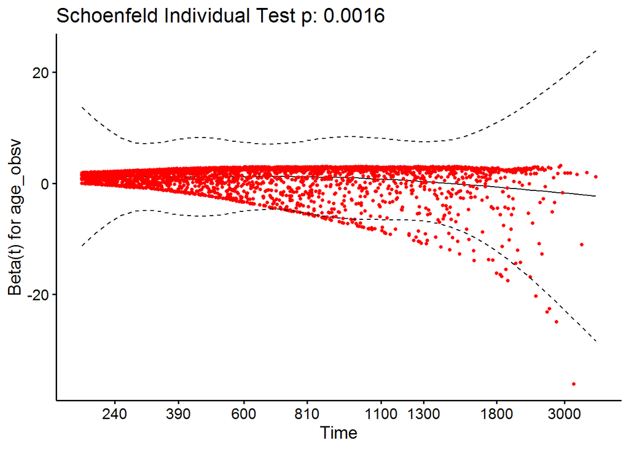

```r
ggcoxzph(resm5)[3]
```

```
## $`3`
```

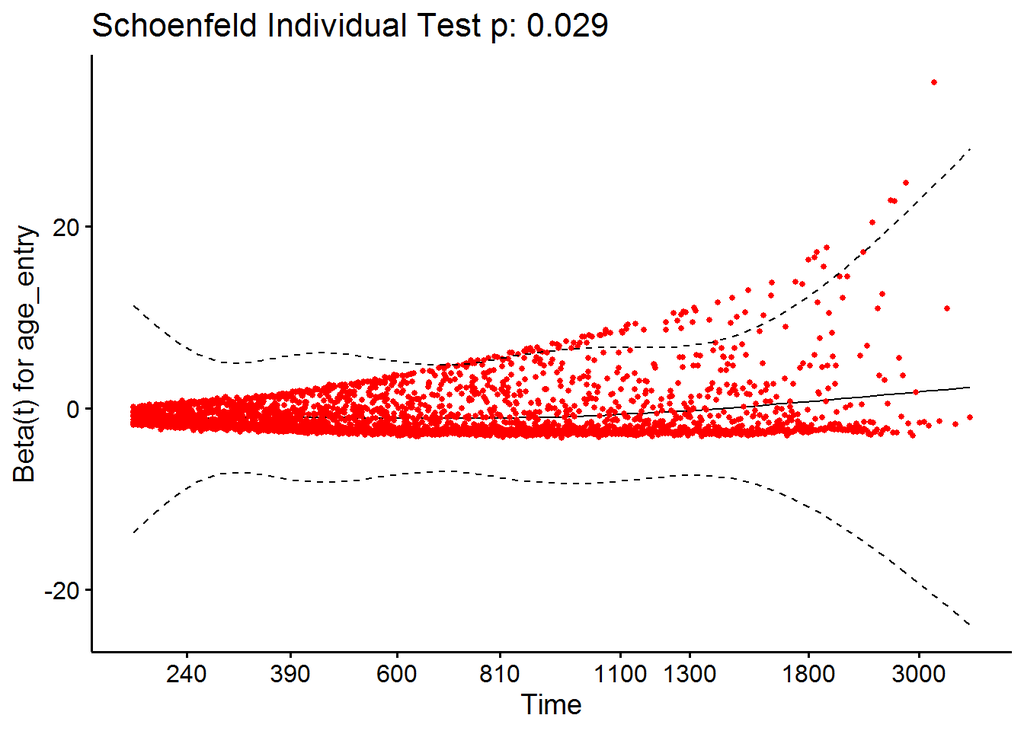

```r
anova(cox_m5)
```

```
## Analysis of Deviance Table
##  Cox model: response is Surv(time1, time2, event_death)
## Terms added sequentially (first to last)
##
##              loglik    Chisq Df Pr(>|Chi|)
## NULL         -23650
## Gender_Value -23649   2.2456  1      0.134
## age_obsv     -23190 918.8934  1     <2e-16 ***
## age_entry    -22802 775.7230  1     <2e-16 ***
## ---
## Signif. codes:  0 '***' 0.001 '**' 0.01 '*' 0.05 '.' 0.1 ' ' 1
```

**Gender, age at observation, and age of diagnosis**

```r
cox_m6 <- coxph(Surv(time1, time2, event_death) ~ Gender_Value + age_obsv + age_diag, data = all_df)

summary(cox_m6)
```

```
## Call:
## coxph(formula = Surv(time1, time2, event_death) ~ Gender_Value +
##     age_obsv + age_diag, data = all_df)
##
##   n= 47952, number of events= 3062
##
##                      coef exp(coef) se(coef)       z Pr(>|z|)
## Gender_ValueMale  0.15754   1.17063  0.03739   4.214 2.51e-05 ***
## age_obsv          0.39097   1.47842  0.01517  25.772  < 2e-16 ***
## age_diag         -0.31315   0.73114  0.01483 -21.116  < 2e-16 ***
## ---
## Signif. codes:  0 '***' 0.001 '**' 0.01 '*' 0.05 '.' 0.1 ' ' 1
##
##                  exp(coef) exp(-coef) lower .95 upper .95
## Gender_ValueMale    1.1706     0.8542    1.0879    1.2596
## age_obsv            1.4784     0.6764    1.4351    1.5230
## age_diag            0.7311     1.3677    0.7102    0.7527
##
## Concordance= 0.682  (se = 0.006 )
## Likelihood ratio test= 1382  on 3 df,   p=<2e-16
## Wald test            = 1204  on 3 df,   p=<2e-16
## Score (logrank) test = 1186  on 3 df,   p=<2e-16
```

```r
cox.zph(cox_m6)
```

```
##               chisq df       p
## Gender_Value  2.497  1 0.11408
## age_obsv      2.187  1 0.13922
## age_diag      0.558  1 0.45495
## GLOBAL       18.284  3 0.00038
```

```r
resm6 <- cox.zph(cox_m6)

ggcoxzph(resm6)[1]
```

```
## $`1`
```

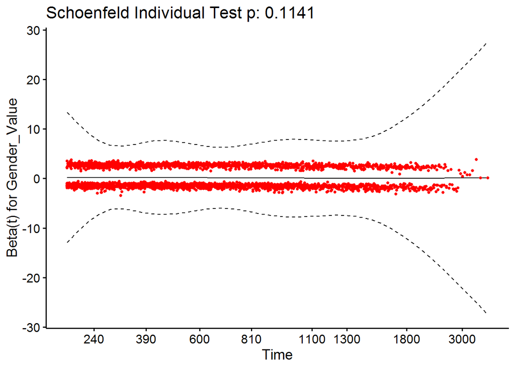

```r
ggcoxzph(resm6)[2]
```

```
## $`2`
```

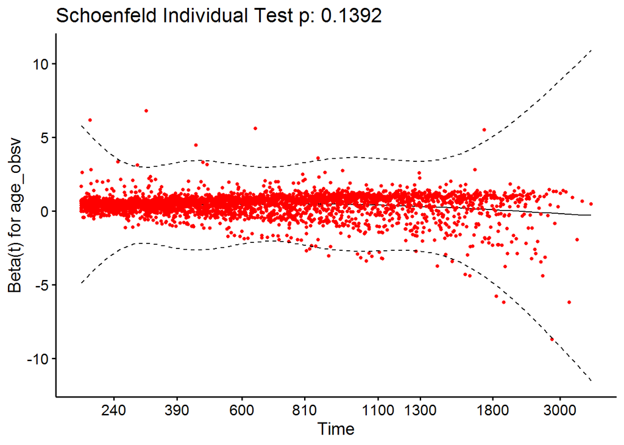

```r
ggcoxzph(resm6)[3]
```

```
## $`3`
```

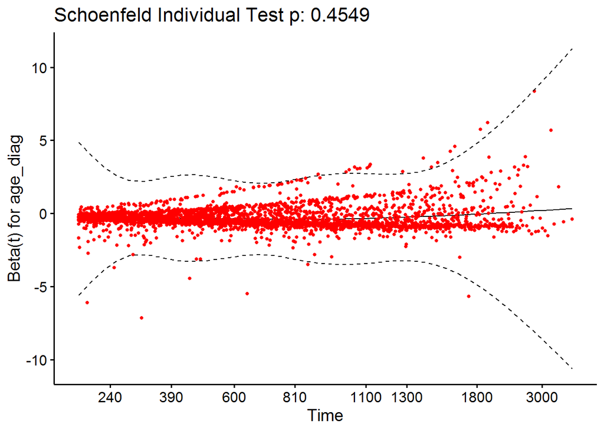

```r
anova(cox_m6)
```

```
## Analysis of Deviance Table
##  Cox model: response is Surv(time1, time2, event_death)
## Terms added sequentially (first to last)
##
##              loglik    Chisq Df Pr(>|Chi|)
## NULL         -23650
## Gender_Value -23649   2.2456  1      0.134
## age_obsv     -23190 918.8934  1     <2e-16 ***
## age_diag     -22959 460.8164  1     <2e-16 ***
## ---
## Signif. codes:  0 '***' 0.001 '**' 0.01 '*' 0.05 '.' 0.1 ' ' 1
```

**Gender, age at observation, and dementia medication exposure**

```r
cox_m7 <- coxph(Surv(time1, time2, event_death) ~ Gender_Value + age_obsv + med_exposure, data = all_df)

summary(cox_m7)
```

```
## Call:
## coxph(formula = Surv(time1, time2, event_death) ~ Gender_Value +
##     age_obsv + med_exposure, data = all_df)
##
##   n= 47952, number of events= 3062
##
##                            coef exp(coef)  se(coef)      z Pr(>|z|)
## Gender_ValueMale       0.207529  1.230634  0.037259  5.570 2.55e-08 ***
## age_obsv               0.078344  1.081495  0.002777 28.215  < 2e-16 ***
## med_exposureunexposed -0.073183  0.929431  0.041058 -1.782   0.0747 .
## ---
## Signif. codes:  0 '***' 0.001 '**' 0.01 '*' 0.05 '.' 0.1 ' ' 1
##
##                       exp(coef) exp(-coef) lower .95 upper .95
## Gender_ValueMale         1.2306     0.8126    1.1440     1.324
## age_obsv                 1.0815     0.9246    1.0756     1.087
## med_exposureunexposed    0.9294     1.0759    0.8576     1.007
##
## Concordance= 0.65  (se = 0.006 )
## Likelihood ratio test= 924.4  on 3 df,   p=<2e-16
## Wald test            = 825  on 3 df,   p=<2e-16
## Score (logrank) test = 836.6  on 3 df,   p=<2e-16
```

```r
cox.zph(cox_m7)
```

```
##                chisq df       p
## Gender_Value  0.0264  1    0.87
## age_obsv      0.2633  1    0.61
## med_exposure 21.1646  1 4.2e-06
## GLOBAL       22.4474  3 5.3e-05
```

```r
resm7 <- cox.zph(cox_m7)

ggcoxzph(resm7)[1]
```

```
## $`1`
```

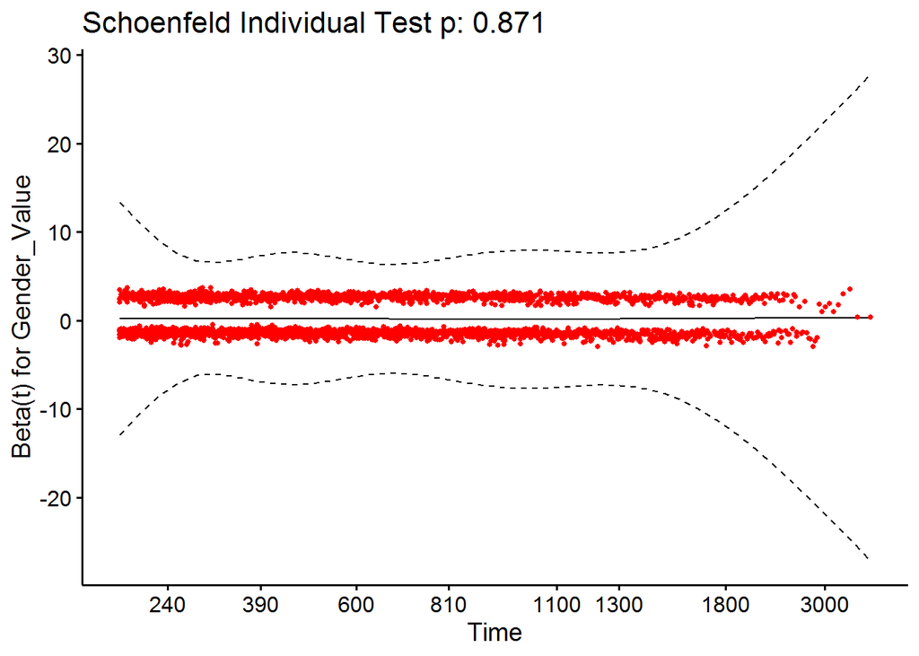

```r
ggcoxzph(resm7)[2]
```

```
## $`2`
```

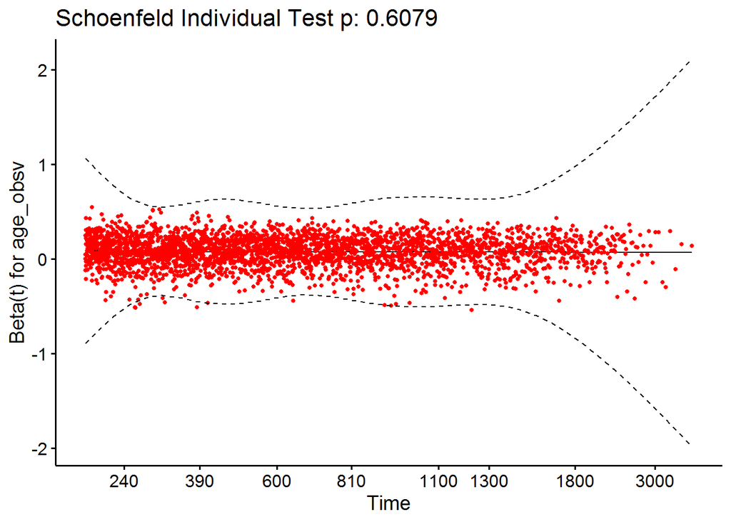

```r
ggcoxzph(resm7)[3]
```

```
## $`3`
```

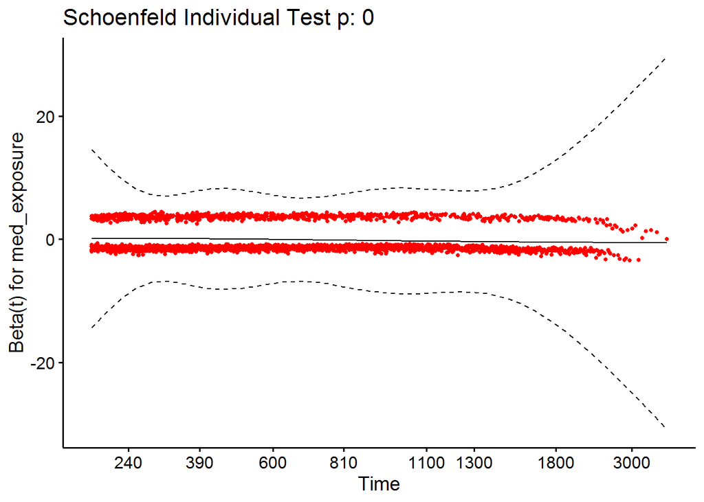

```r
anova(cox_m7)
```

```
## Analysis of Deviance Table
##  Cox model: response is Surv(time1, time2, event_death)
## Terms added sequentially (first to last)
##
##              loglik    Chisq Df Pr(>|Chi|)
## NULL         -23650
## Gender_Value -23649   2.2456  1    0.13400
## age_obsv     -23190 918.8934  1    < 2e-16 ***
## med_exposure -23188   3.2108  1    0.07315 .
## ---
## Signif. codes:  0 '***' 0.001 '**' 0.01 '*' 0.05 '.' 0.1 ' ' 1
```

**Gender, age at observation, and initial diagnosis**

```r
cox_m8 <- coxph(Surv(time1, time2, event_death) ~ Gender_Value + age_obsv + cause_diagper,
                data = all_df)

summary(cox_m8)
```

```
## Call:
## coxph(formula = Surv(time1, time2, event_death) ~ Gender_Value +
##     age_obsv + cause_diagper, data = all_df)
##
##   n= 47952, number of events= 3062
##
##                               coef exp(coef)  se(coef)      z Pr(>|z|)
## Gender_ValueMale          0.207913  1.231106  0.037293  5.575 2.47e-08 ***
## age_obsv                  0.078720  1.081901  0.002761 28.510  < 2e-16 ***
## cause_diagperDLB          0.231236  1.260156  0.118144  1.957 0.050319 .
## cause_diagperFTD         -0.066852  0.935333  0.269491 -0.248 0.804081
## cause_diagperMixedADVaD   0.200669  1.222221  0.169560  1.183 0.236621
## cause_diagperPPD          0.109649  1.115886  0.501198  0.219 0.826827
## cause_diagperUnspecified  0.047449  1.048592  0.039081  1.214 0.224709
## cause_diagperVaD          0.293938  1.341700  0.082053  3.582 0.000341 ***
## ---
## Signif. codes:  0 '***' 0.001 '**' 0.01 '*' 0.05 '.' 0.1 ' ' 1
##
##                          exp(coef) exp(-coef) lower .95 upper .95
## Gender_ValueMale            1.2311     0.8123    1.1443     1.324
## age_obsv                    1.0819     0.9243    1.0761     1.088
## cause_diagperDLB            1.2602     0.7936    0.9997     1.589
## cause_diagperFTD            0.9353     1.0691    0.5515     1.586
## cause_diagperMixedADVaD     1.2222     0.8182    0.8766     1.704
## cause_diagperPPD            1.1159     0.8961    0.4178     2.980
## cause_diagperUnspecified    1.0486     0.9537    0.9713     1.132
## cause_diagperVaD            1.3417     0.7453    1.1424     1.576
##
## Concordance= 0.652  (se = 0.006 )
## Likelihood ratio test= 936.7  on 8 df,   p=<2e-16
## Wald test            = 838.5  on 8 df,   p=<2e-16
## Score (logrank) test = 850.3  on 8 df,   p=<2e-16
```

```r
cox.zph(cox_m8)
```

```
##                 chisq df      p
## Gender_Value   0.0185  1 0.8918
## age_obsv       0.2117  1 0.6454
## cause_diagper 16.8500  6 0.0099
## GLOBAL        17.2261  8 0.0278
```

```r
resm8 <- cox.zph(cox_m8)

ggcoxzph(resm8)[1]
```

```
## $`1`
```

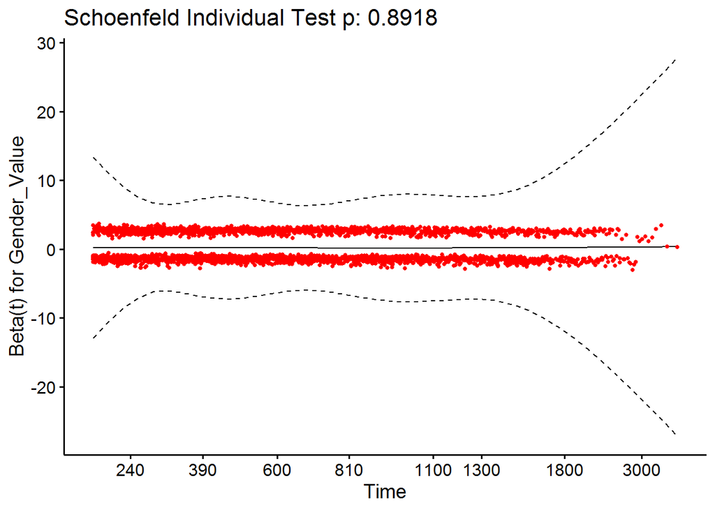

```r
ggcoxzph(resm8)[2]
```

```
## $`2`
```

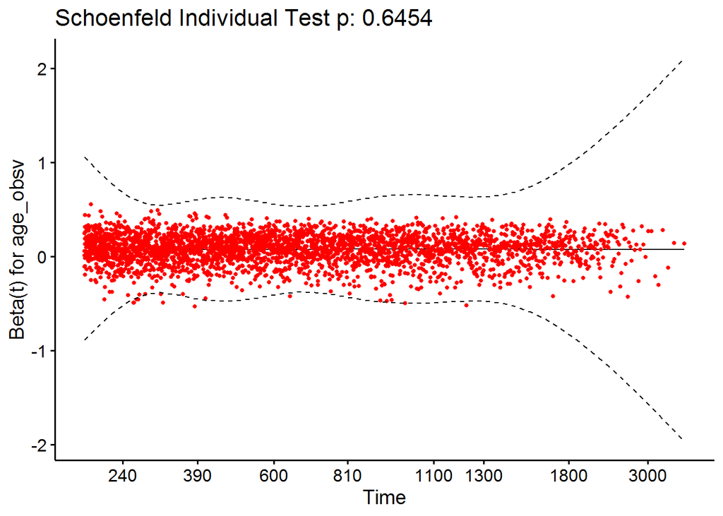

```r
ggcoxzph(resm8)[3]
```

```
## $`3`
```

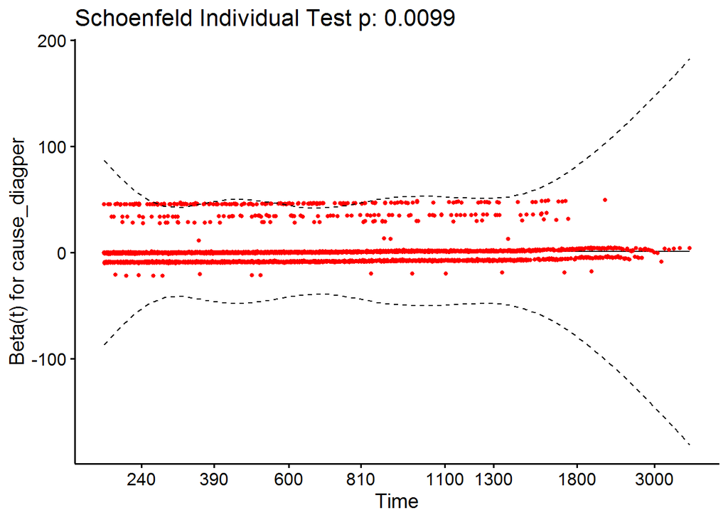

```r
anova(cox_m8)
```

```
## Analysis of Deviance Table
##  Cox model: response is Surv(time1, time2, event_death)
## Terms added sequentially (first to last)
##
##               loglik    Chisq Df Pr(>|Chi|)
## NULL          -23650
## Gender_Value  -23649   2.2456  1    0.13400
## age_obsv      -23190 918.8934  1    < 2e-16 ***
## cause_diagper -23182  15.5356  6    0.01648 *
## ---
## Signif. codes:  0 '***' 0.001 '**' 0.01 '*' 0.05 '.' 0.1 ' ' 1
```

**Gender, age at observation, and racial group**

```r
cox_m9 <- coxph(Surv(time1, time2, event_death) ~ Gender_Value + age_obsv + Ethnicity_Value, data = all_df)

summary(cox_m9)
```

```
## Call:
## coxph(formula = Surv(time1, time2, event_death) ~ Gender_Value +
##     age_obsv + Ethnicity_Value, data = all_df)
##
##   n= 37149, number of events= 2435
##    (10803 observations deleted due to missingness)
##
##                           coef exp(coef)  se(coef)      z Pr(>|z|)
## Gender_ValueMale      0.177842  1.194636  0.042015  4.233 2.31e-05 ***
## age_obsv              0.077335  1.080404  0.003062 25.260  < 2e-16 ***
## Ethnicity_ValueOther  0.043311  1.044262  0.205656  0.211   0.8332
## Ethnicity_ValueAsian -0.207120  0.812922  0.244083 -0.849   0.3961
## Ethnicity_ValueBlack  0.471850  1.602957  0.243585  1.937   0.0527 .
## ---
## Signif. codes:  0 '***' 0.001 '**' 0.01 '*' 0.05 '.' 0.1 ' ' 1
##
##                      exp(coef) exp(-coef) lower .95 upper .95
## Gender_ValueMale        1.1946     0.8371    1.1002     1.297
## age_obsv                1.0804     0.9256    1.0739     1.087
## Ethnicity_ValueOther    1.0443     0.9576    0.6978     1.563
## Ethnicity_ValueAsian    0.8129     1.2301    0.5038     1.312
## Ethnicity_ValueBlack    1.6030     0.6238    0.9944     2.584
##
## Concordance= 0.652  (se = 0.006 )
## Likelihood ratio test= 723.2  on 5 df,   p=<2e-16
## Wald test            = 646.2  on 5 df,   p=<2e-16
## Score (logrank) test = 657.4  on 5 df,   p=<2e-16
```

```r
cox.zph(cox_m9)
```

```
##                  chisq df    p
## Gender_Value    0.0263  1 0.87
## age_obsv        0.4251  1 0.51
## Ethnicity_Value 4.4021  3 0.22
## GLOBAL          4.9290  5 0.42
```

```r
resm9 <- cox.zph(cox_m9)

ggcoxzph(resm9)[1]
```

```
## $`1`
```

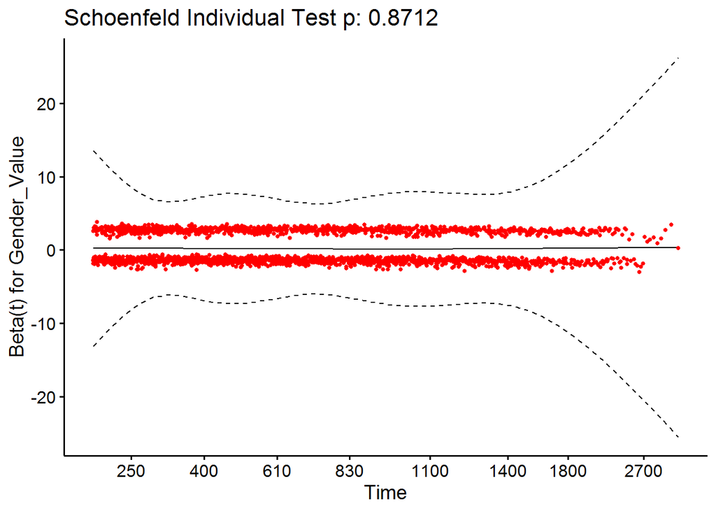

```r
ggcoxzph(resm9)[2]
```

```
## $`2`
```

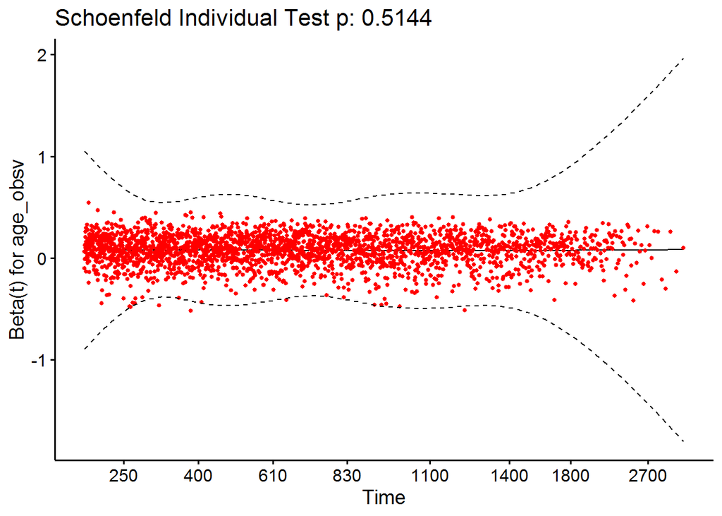

```r
ggcoxzph(resm9)[3]
```

```
## $`3`
```

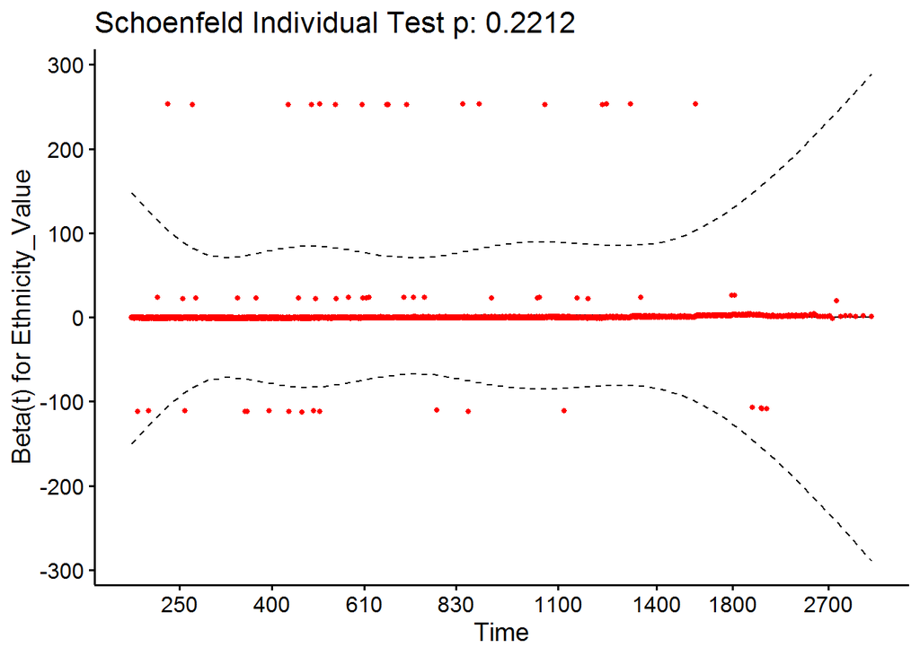

```r
anova(cox_m9)
```

```
## Analysis of Deviance Table
##  Cox model: response is Surv(time1, time2, event_death)
## Terms added sequentially (first to last)
##
##                 loglik    Chisq Df Pr(>|Chi|)
## NULL            -18164
## Gender_Value    -18164   0.1469  1     0.7015
## age_obsv        -17804 718.9659  1     <2e-16 ***
## Ethnicity_Value -17802   4.0689  3     0.2541
## ---
## Signif. codes:  0 '***' 0.001 '**' 0.01 '*' 0.05 '.' 0.1 ' ' 1
```

**Gender, age at observation, and dementia medication class**

```r
cox_m10 <- coxph(Surv(time1, time2, event_death) ~ Gender_Value + age_obsv + type_medclass, data = all_df)

summary(cox_m10)
```

```
## Call:
## coxph(formula = Surv(time1, time2, event_death) ~ Gender_Value +
##     age_obsv + type_medclass, data = all_df)
##
##   n= 35001, number of events= 2092
##    (12951 observations deleted due to missingness)
##
##                            coef exp(coef) se(coef)      z Pr(>|z|)
## Gender_ValueMale       0.149674  1.161456 0.045073  3.321 0.000898 ***
## age_obsv               0.074153  1.076971 0.003542 20.933  < 2e-16 ***
## type_medclassMementine 0.660400  1.935567 0.055492 11.901  < 2e-16 ***
## ---
## Signif. codes:  0 '***' 0.001 '**' 0.01 '*' 0.05 '.' 0.1 ' ' 1
##
##                        exp(coef) exp(-coef) lower .95 upper .95
## Gender_ValueMale           1.161     0.8610     1.063     1.269
## age_obsv                   1.077     0.9285     1.070     1.084
## type_medclassMementine     1.936     0.5166     1.736     2.158
##
## Concordance= 0.655  (se = 0.007 )
## Likelihood ratio test= 590.3  on 3 df,   p=<2e-16
## Wald test            = 578.9  on 3 df,   p=<2e-16
## Score (logrank) test = 584  on 3 df,   p=<2e-16
```

```r
cox.zph(cox_m10)
```

```
##               chisq df      p
## Gender_Value  0.400  1 0.5273
## age_obsv      7.344  1 0.0067
## type_medclass 0.669  1 0.4133
## GLOBAL        8.838  3 0.0315
```

```r
resm10 <- cox.zph(cox_m10)

ggcoxzph(resm10)[1]
```

```
## $`1`
```

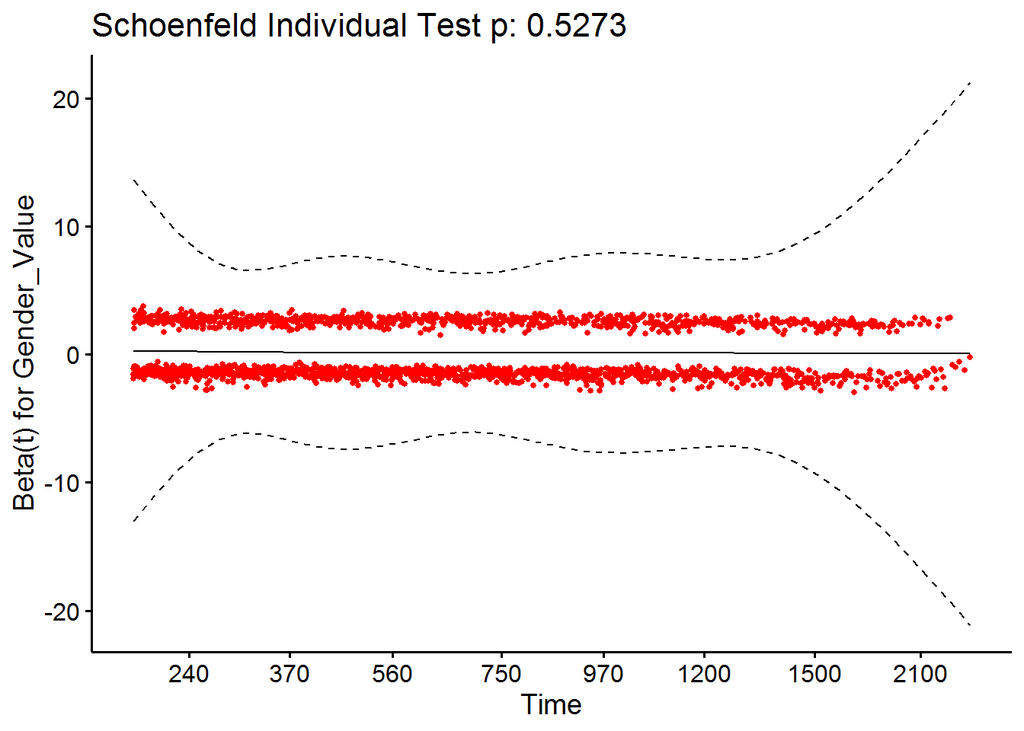

```r
ggcoxzph(resm10)[2]
```

```
## $`2`
```

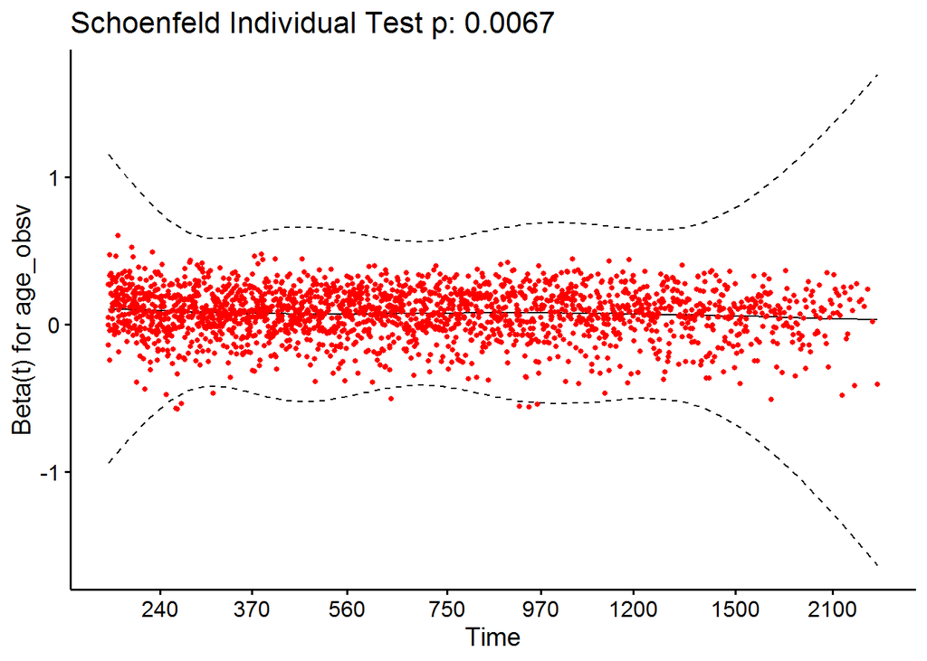

```r
ggcoxzph(resm10)[3]
```

```
## $`3`
```

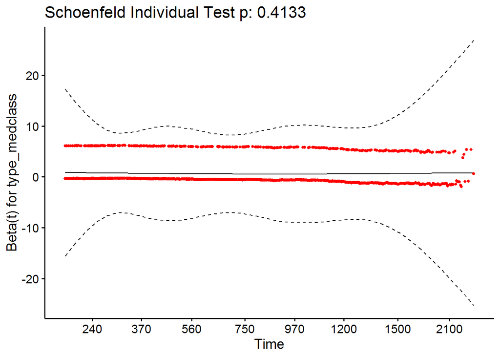

```r
anova(cox_m10)
```

```
## Analysis of Deviance Table
##  Cox model: response is Surv(time1, time2, event_death)
## Terms added sequentially (first to last)
##
##               loglik    Chisq Df Pr(>|Chi|)
## NULL          -15086
## Gender_Value  -15086   0.1336  1     0.7148
## age_obsv      -14853 466.3114  1     <2e-16 ***
## type_medclass -14791 123.8357  1     <2e-16 ***
## ---
## Signif. codes:  0 '***' 0.001 '**' 0.01 '*' 0.05 '.' 0.1 ' ' 1
```

Based on proportionality test, we removed age at observation

**Gender and dementia medication class**

```r
cox_m10a <- coxph(Surv(time1, time2, event_death) ~ Gender_Value + type_medclass, data = all_df)

summary(cox_m10a)
```

```
## Call:
## coxph(formula = Surv(time1, time2, event_death) ~ Gender_Value +
##     type_medclass, data = all_df)
##
##   n= 35001, number of events= 2092
##    (12951 observations deleted due to missingness)
##
##                           coef exp(coef) se(coef)      z Pr(>|z|)
## Gender_ValueMale       0.01840   1.01857  0.04449  0.414    0.679
## type_medclassMementine 0.63501   1.88704  0.05545 11.453   <2e-16 ***
## ---
## Signif. codes:  0 '***' 0.001 '**' 0.01 '*' 0.05 '.' 0.1 ' ' 1
##
##                        exp(coef) exp(-coef) lower .95 upper .95
## Gender_ValueMale           1.019     0.9818    0.9335     1.111
## type_medclassMementine     1.887     0.5299    1.6927     2.104
##
## Concordance= 0.537  (se = 0.007 )
## Likelihood ratio test= 115.4  on 2 df,   p=<2e-16
## Wald test            = 131.3  on 2 df,   p=<2e-16
## Score (logrank) test = 135.6  on 2 df,   p=<2e-16
```

```r
cox.zph(cox_m10a)
```

```
##                 chisq df    p
## Gender_Value  0.00177  1 0.97
## type_medclass 0.69974  1 0.40
## GLOBAL        0.70020  2 0.70
```

```r
resm10a <- cox.zph(cox_m10a)

ggcoxzph(resm10a)[1]
```

```
## $`1`
```

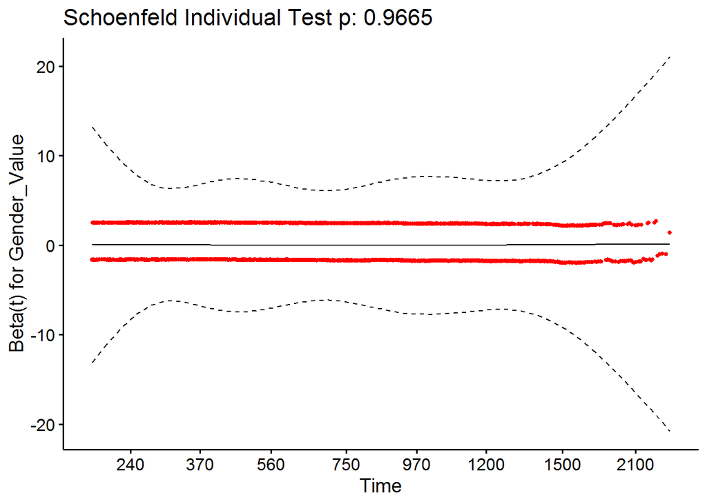

```r
ggcoxzph(resm10a)[2]
```

```
## $`2`
```

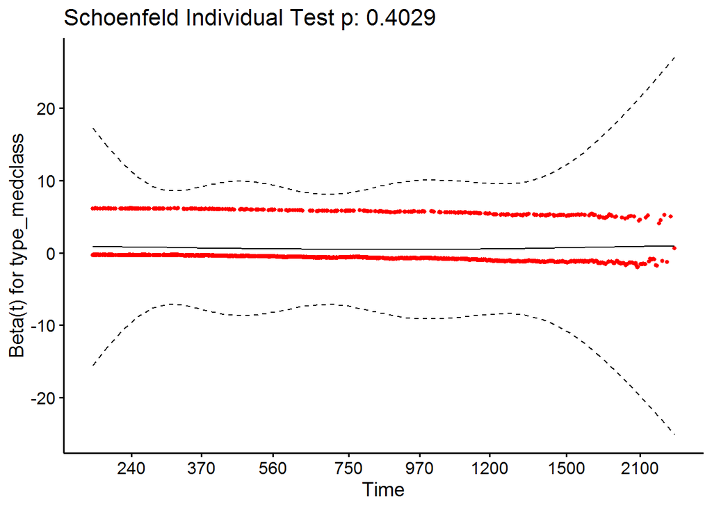

```r
anova(cox_m10)
```

```
## Analysis of Deviance Table
##  Cox model: response is Surv(time1, time2, event_death)
## Terms added sequentially (first to last)
##
##               loglik    Chisq Df Pr(>|Chi|)
## NULL          -15086
## Gender_Value  -15086   0.1336  1     0.7148
## age_obsv      -14853 466.3114  1     <2e-16 ***
## type_medclass -14791 123.8357  1     <2e-16 ***
## ---
## Signif. codes:  0 '***' 0.001 '**' 0.01 '*' 0.05 '.' 0.1 ' ' 1
```

Gender was not a significant predictor in the model above, so if we remove it we’re back to a univariate model

**Gender, age at observation, and marital_status**

```r
cox_m11 <- coxph(Surv(time1, time2, event_death) ~ Gender_Value + age_obsv + marital_status, data = all_df)

summary(cox_m11)
```

```
## Call:
## coxph(formula = Surv(time1, time2, event_death) ~ Gender_Value +
##     age_obsv + marital_status, data = all_df)
##
##   n= 32174, number of events= 2052
##    (15778 observations deleted due to missingness)
##
##                                       coef exp(coef)  se(coef)      z Pr(>|z|)
## Gender_ValueMale                  0.186455  1.204971  0.047931  3.890   0.0001
## age_obsv                          0.079305  1.082534  0.003480 22.788   <2e-16
## marital_statusDivorced/Separated -0.048788  0.952383  0.121712 -0.401   0.6885
## marital_statusSingle              0.070431  1.072970  0.088060  0.800   0.4238
## marital_statusWidowed             0.007716  1.007746  0.052160  0.148   0.8824
##
## Gender_ValueMale                 ***
## age_obsv                         ***
## marital_statusDivorced/Separated
## marital_statusSingle
## marital_statusWidowed
## ---
## Signif. codes:  0 '***' 0.001 '**' 0.01 '*' 0.05 '.' 0.1 ' ' 1
##
##                                  exp(coef) exp(-coef) lower .95 upper .95
## Gender_ValueMale                    1.2050     0.8299    1.0969     1.324
## age_obsv                            1.0825     0.9238    1.0752     1.090
## marital_statusDivorced/Separated    0.9524     1.0500    0.7503     1.209
## marital_statusSingle                1.0730     0.9320    0.9029     1.275
## marital_statusWidowed               1.0077     0.9923    0.9098     1.116
##
## Concordance= 0.656  (se = 0.007 )
## Likelihood ratio test= 639.1  on 5 df,   p=<2e-16
## Wald test            = 568.5  on 5 df,   p=<2e-16
## Score (logrank) test = 581.4  on 5 df,   p=<2e-16
```

```r
cox.zph(cox_m11)
```

```
##                chisq df    p
## Gender_Value   0.359  1 0.55
## age_obsv       0.393  1 0.53
## marital_status 3.512  3 0.32
## GLOBAL         4.395  5 0.49
```

```r
resm11 <- cox.zph(cox_m11)

ggcoxzph(resm11)[1]
```

```
## $`1`
```

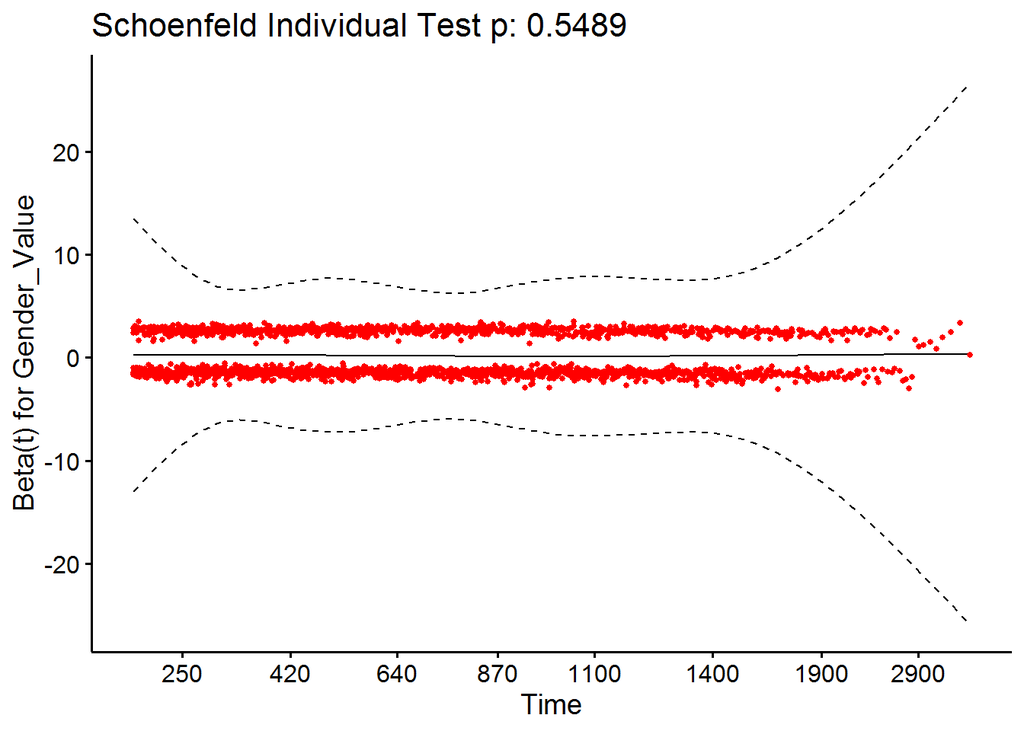

```r
ggcoxzph(resm11)[2]
```

```
## $`2`
```

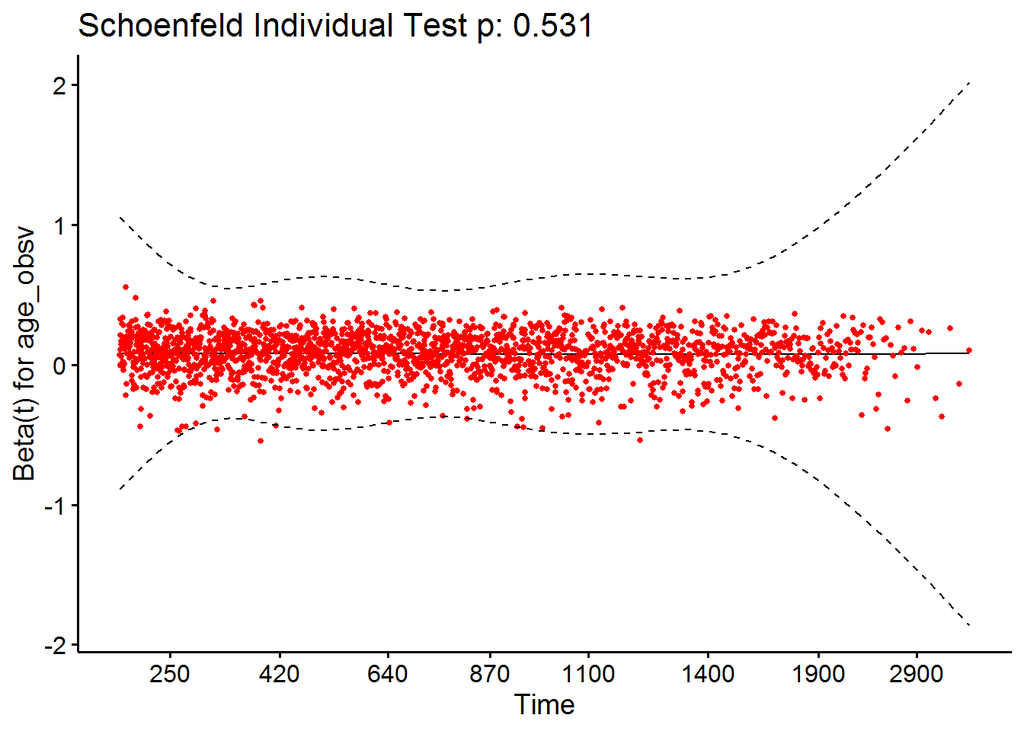

```r
ggcoxzph(resm11)[3]
```

```
## $`3`
```

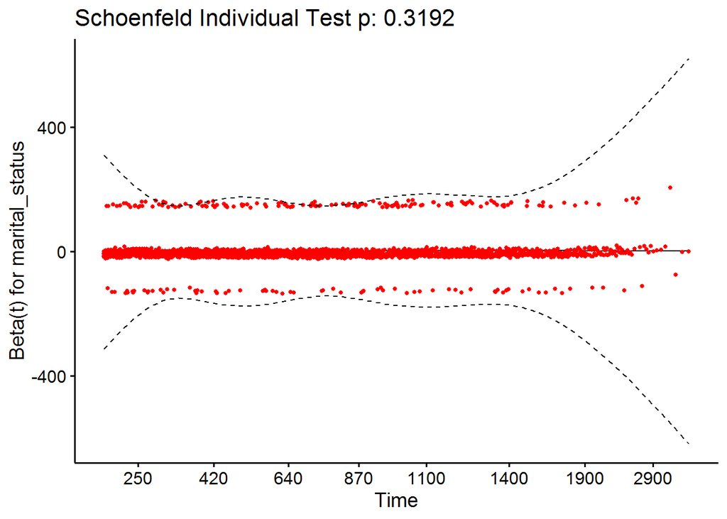

```r
anova(cox_m11)
```

```
## Analysis of Deviance Table
##  Cox model: response is Surv(time1, time2, event_death)
## Terms added sequentially (first to last)
##
##                loglik    Chisq Df Pr(>|Chi|)
## NULL           -14966
## Gender_Value   -14965   0.9696  1     0.3248
## age_obsv       -14647 637.2531  1     <2e-16 ***
## marital_status -14646   0.8651  3     0.8338
## ---
## Signif. codes:  0 '***' 0.001 '**' 0.01 '*' 0.05 '.' 0.1 ' ' 1
```

**Gender, age at observation, and type of cognitive assessment**

```r
cox_m12 <- coxph(Surv(time1, time2, event_death) ~ Gender_Value + age_obsv + type_cogeval, data = all_df)

summary(cox_m12)
```

```
## Call:
## coxph(formula = Surv(time1, time2, event_death) ~ Gender_Value +
##     age_obsv + type_cogeval, data = all_df)
##
##   n= 18330, number of events= 1241
##    (29622 observations deleted due to missingness)
##
##                      coef exp(coef) se(coef)      z Pr(>|z|)
## Gender_ValueMale 0.224227  1.251355 0.058567  3.829 0.000129 ***
## age_obsv         0.083168  1.086724 0.004555 18.260  < 2e-16 ***
## type_cogevalMOCA 0.010035  1.010086 0.068123  0.147 0.882885
## ---
## Signif. codes:  0 '***' 0.001 '**' 0.01 '*' 0.05 '.' 0.1 ' ' 1
##
##                  exp(coef) exp(-coef) lower .95 upper .95
## Gender_ValueMale     1.251     0.7991    1.1157     1.404
## age_obsv             1.087     0.9202    1.0771     1.096
## type_cogevalMOCA     1.010     0.9900    0.8838     1.154
##
## Concordance= 0.65  (se = 0.009 )
## Likelihood ratio test= 372.6  on 3 df,   p=<2e-16
## Wald test            = 335  on 3 df,   p=<2e-16
## Score (logrank) test = 341.1  on 3 df,   p=<2e-16
```

```r
cox.zph(cox_m12)
```

```
##               chisq df     p
## Gender_Value 0.0427  1 0.836
## age_obsv     0.1053  1 0.746
## type_cogeval 3.8766  1 0.049
## GLOBAL       4.0692  3 0.254
```

```r
resm12 <- cox.zph(cox_m12)

ggcoxzph(resm12)[1]
```

```
## $`1`
```

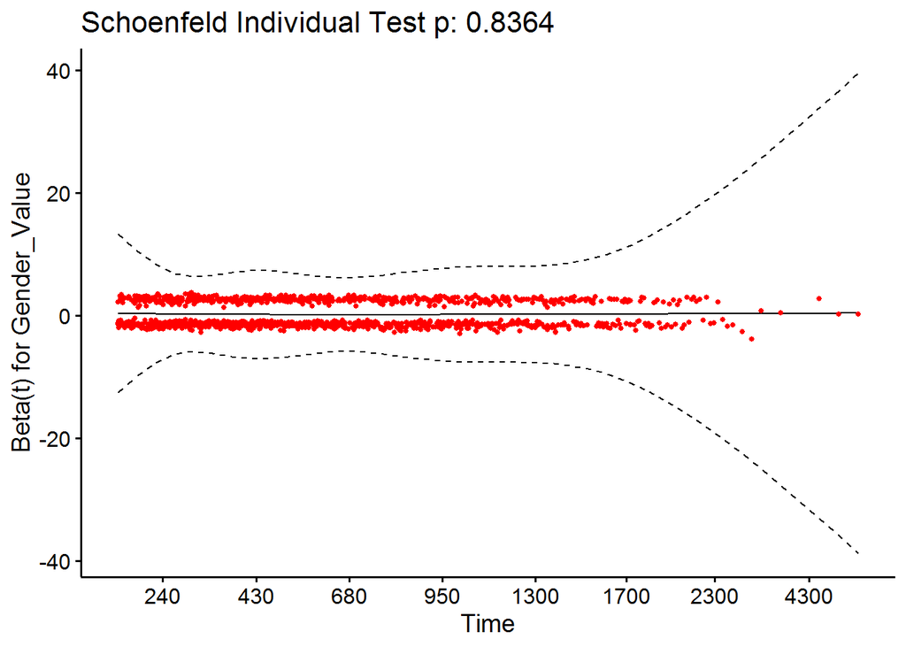

```r
ggcoxzph(resm12)[2]
```

```
## $`2`
```

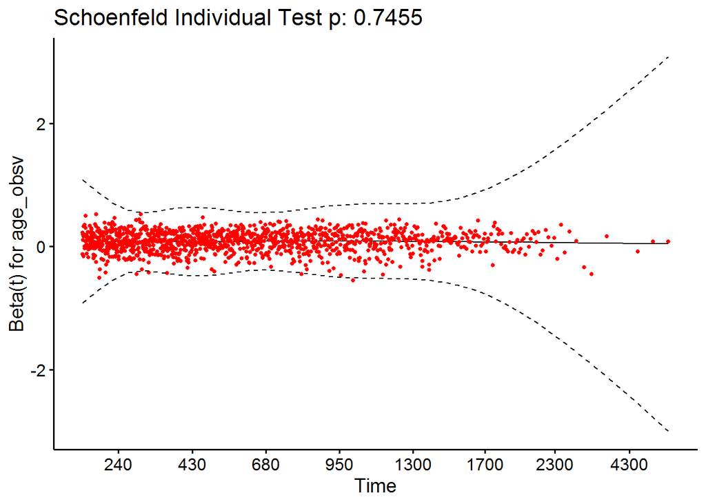

```r
ggcoxzph(resm12)[3]
```

```
## $`3`
```

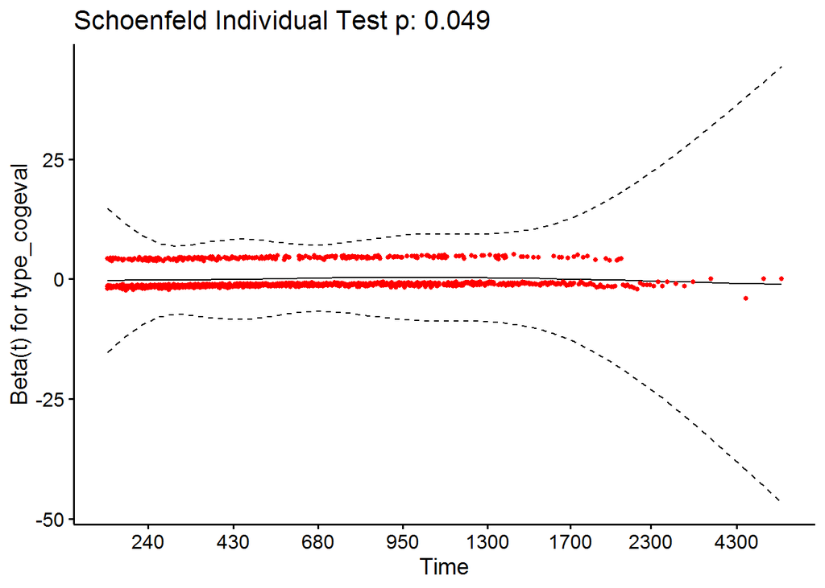

```r
anova(cox_m12)
```

```
## Analysis of Deviance Table
##  Cox model: response is Surv(time1, time2, event_death)
## Terms added sequentially (first to last)
##
##               loglik    Chisq Df Pr(>|Chi|)
## NULL         -8750.3
## Gender_Value -8750.0   0.6222  1     0.4302
## age_obsv     -8564.0 371.9242  1     <2e-16 ***
## type_cogeval -8564.0   0.0217  1     0.8830
## ---
## Signif. codes:  0 '***' 0.001 '**' 0.01 '*' 0.05 '.' 0.1 ' ' 1
```

**Gender, age at observation, and score in cognitive assessment**

```r
cox_m13 <- coxph(Surv(time1, time2, event_death) ~ Gender_Value + age_obsv + numerator, data = all_df)

summary(cox_m13)
```

```
## Call:
## coxph(formula = Surv(time1, time2, event_death) ~ Gender_Value +
##     age_obsv + numerator, data = all_df)
##
##   n= 18330, number of events= 1241
##    (29622 observations deleted due to missingness)
##
##                       coef exp(coef)  se(coef)       z Pr(>|z|)
## Gender_ValueMale  0.240449  1.271820  0.058473   4.112 3.92e-05 ***
## age_obsv          0.079801  1.083072  0.004536  17.593  < 2e-16 ***
## numerator        -0.043041  0.957872  0.004002 -10.754  < 2e-16 ***
## ---
## Signif. codes:  0 '***' 0.001 '**' 0.01 '*' 0.05 '.' 0.1 ' ' 1
##
##                  exp(coef) exp(-coef) lower .95 upper .95
## Gender_ValueMale    1.2718     0.7863    1.1341    1.4263
## age_obsv            1.0831     0.9233    1.0735    1.0927
## numerator           0.9579     1.0440    0.9504    0.9654
##
## Concordance= 0.67  (se = 0.009 )
## Likelihood ratio test= 481.2  on 3 df,   p=<2e-16
## Wald test            = 444.5  on 3 df,   p=<2e-16
## Score (logrank) test = 451.2  on 3 df,   p=<2e-16
```

```r
cox.zph(cox_m13)
```

```
##              chisq df    p
## Gender_Value 0.330  1 0.57
## age_obsv     0.289  1 0.59
## numerator    1.031  1 0.31
## GLOBAL       1.911  3 0.59
```

```r
resm13 <- cox.zph(cox_m13)

ggcoxzph(resm13)[1]
```

```
## $`1`
```

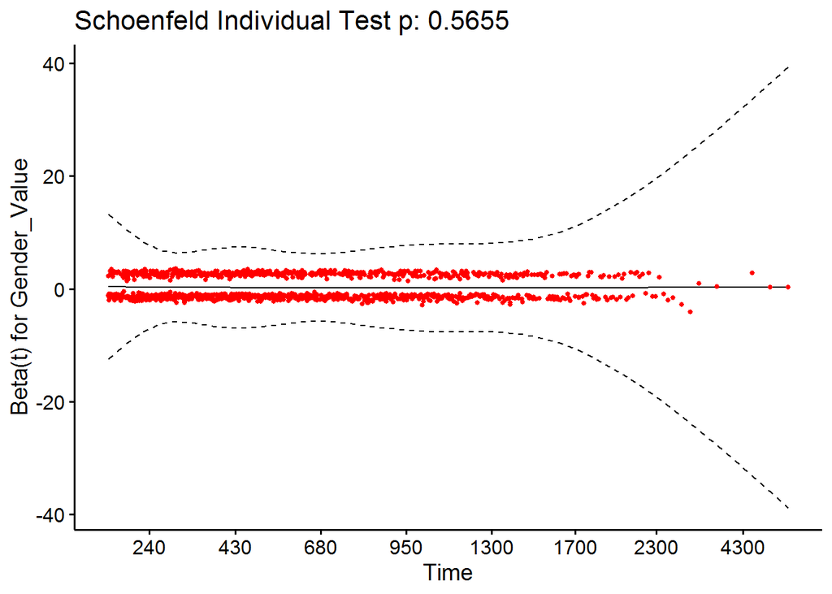

```r
ggcoxzph(resm13)[2]
```

```
## $`2`
```

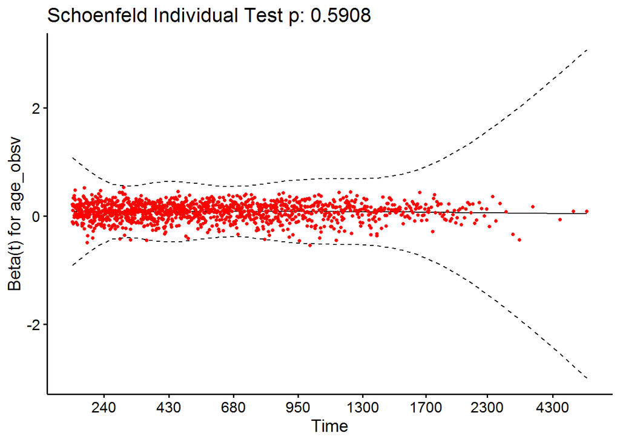

```r
ggcoxzph(resm13)[3]
```

```
## $`3`
```

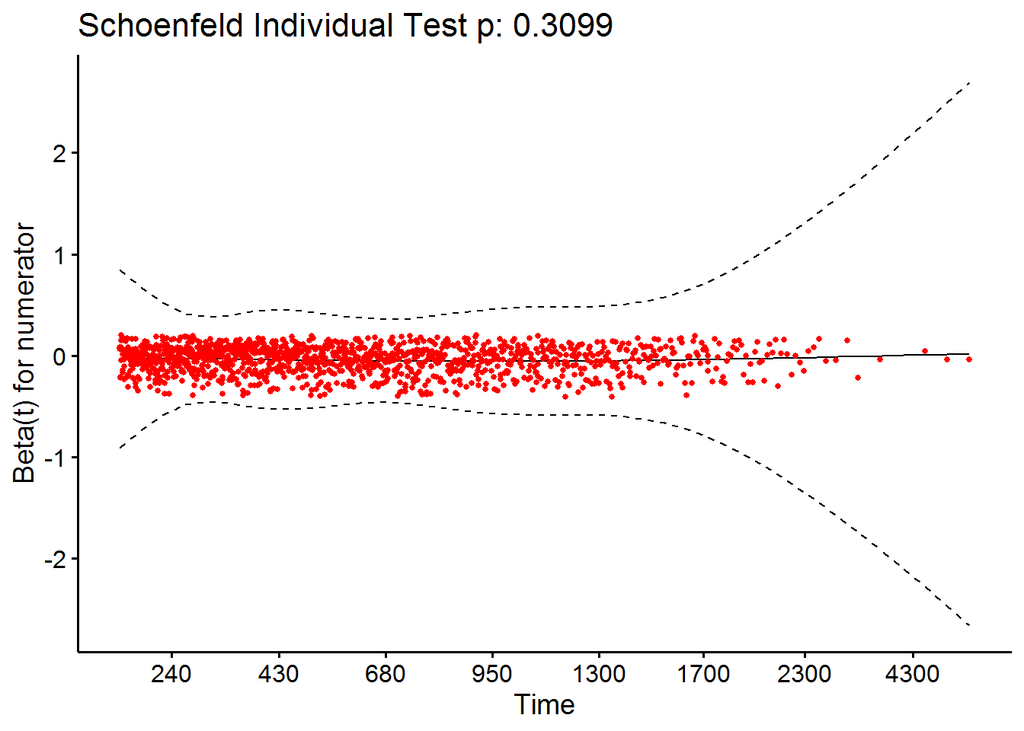

```r
anova(cox_m13)
```

```
## Analysis of Deviance Table
##  Cox model: response is Surv(time1, time2, event_death)
## Terms added sequentially (first to last)
##
##               loglik    Chisq Df Pr(>|Chi|)
## NULL         -8750.3
## Gender_Value -8750.0   0.6222  1     0.4302
## age_obsv     -8564.0 371.9242  1     <2e-16 ***
## numerator    -8509.7 108.6918  1     <2e-16 ***
## ---
## Signif. codes:  0 '***' 0.001 '**' 0.01 '*' 0.05 '.' 0.1 ' ' 1
```

*Forest plot*

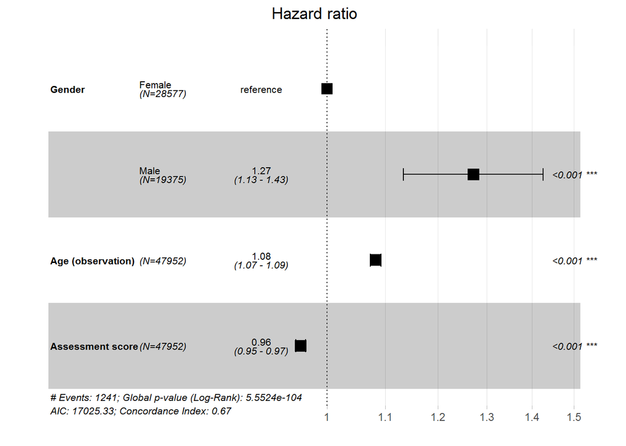

```r
forest_df13 <- all_df %>%
  transmute(time1,
            time2,
            event_death,
            Gender = factor(Gender_Value),
            `Age (observation)` = age_obsv,
            `Assessment score` = numerator) %>%
  mutate(Gender = relevel(Gender, ref = "Female"))

new13 <- coxph(Surv(time1, time2, event_death) ~ Gender + `Age (observation)` + `Assessment score`, data = forest_df13)

ggforest(new13,
         cpositions = c(0.003, 0.17, 0.4))
```

**Gender, age at observation, and chronic medication use**

```r
cox_m14 <- coxph(Surv(time1, time2, event_death) ~ Gender_Value + age_obsv + medother_grouped, data = all_df)

summary(cox_m14)
```

```
## Call:
## coxph(formula = Surv(time1, time2, event_death) ~ Gender_Value +
##     age_obsv + medother_grouped, data = all_df)
##
##   n= 15637, number of events= 855
##    (32315 observations deleted due to missingness)
##
##                                coef exp(coef)  se(coef)      z Pr(>|z|)
## Gender_ValueMale           0.383309  1.467132  0.071269  5.378 7.52e-08 ***
## age_obsv                   0.067021  1.069318  0.005122 13.086  < 2e-16 ***
## medother_groupedInsulin   -0.490768  0.612156  0.222680 -2.204 0.027530 *
## medother_groupedSNRIs     -0.349214  0.705242  0.227524 -1.535 0.124823
## medother_groupedSSRIs     -0.301485  0.739719  0.091583 -3.292 0.000995 ***
## medother_groupedTCAs      -0.597708  0.550071  0.228111 -2.620 0.008786 **
## medother_groupedTeCAs     -0.264084  0.767909  0.114037 -2.316 0.020571 *
## medother_groupedTrazodone  0.114176  1.120950  0.095645  1.194 0.232573
## ---
## Signif. codes:  0 '***' 0.001 '**' 0.01 '*' 0.05 '.' 0.1 ' ' 1
##
##                           exp(coef) exp(-coef) lower .95 upper .95
## Gender_ValueMale             1.4671     0.6816    1.2759    1.6871
## age_obsv                     1.0693     0.9352    1.0586    1.0801
## medother_groupedInsulin      0.6122     1.6336    0.3957    0.9471
## medother_groupedSNRIs        0.7052     1.4180    0.4515    1.1016
## medother_groupedSSRIs        0.7397     1.3519    0.6182    0.8852
## medother_groupedTCAs         0.5501     1.8179    0.3518    0.8602
## medother_groupedTeCAs        0.7679     1.3022    0.6141    0.9602
## medother_groupedTrazodone    1.1209     0.8921    0.9293    1.3521
##
## Concordance= 0.651  (se = 0.011 )
## Likelihood ratio test= 238.1  on 8 df,   p=<2e-16
## Wald test            = 225.6  on 8 df,   p=<2e-16
## Score (logrank) test = 229.3  on 8 df,   p=<2e-16
```

```r
cox.zph(cox_m14)
```

```
##                     chisq df    p
## Gender_Value     0.000462  1 0.98
## age_obsv         0.070665  1 0.79
## medother_grouped 2.179829  6 0.90
## GLOBAL           2.232254  8 0.97
```

```r
resm14 <- cox.zph(cox_m14)

ggcoxzph(resm14)[1]
```

```
## $`1`
```

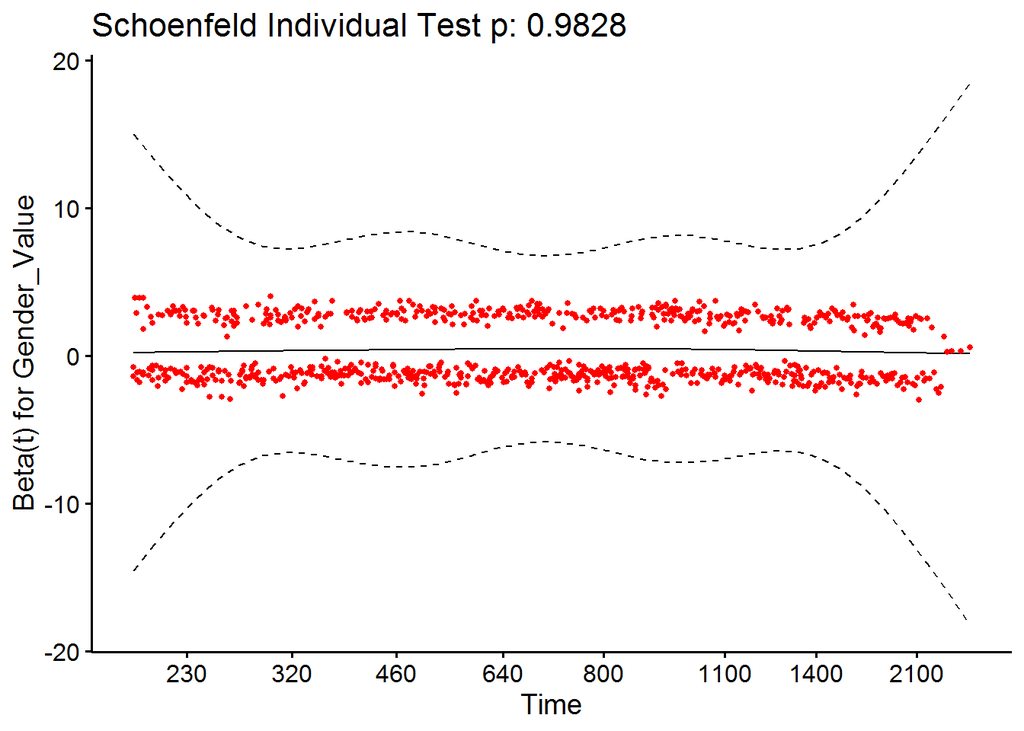

```r
ggcoxzph(resm14)[2]
```

```
## $`2`
```

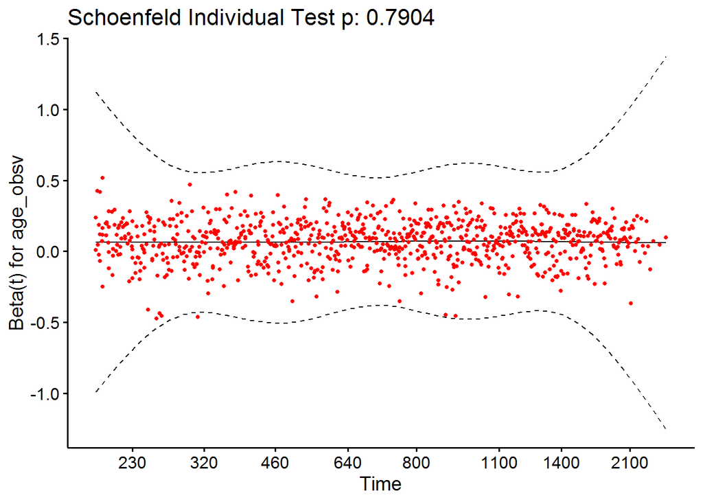

```r
ggcoxzph(resm14)[3]
```

```
## $`3`
```

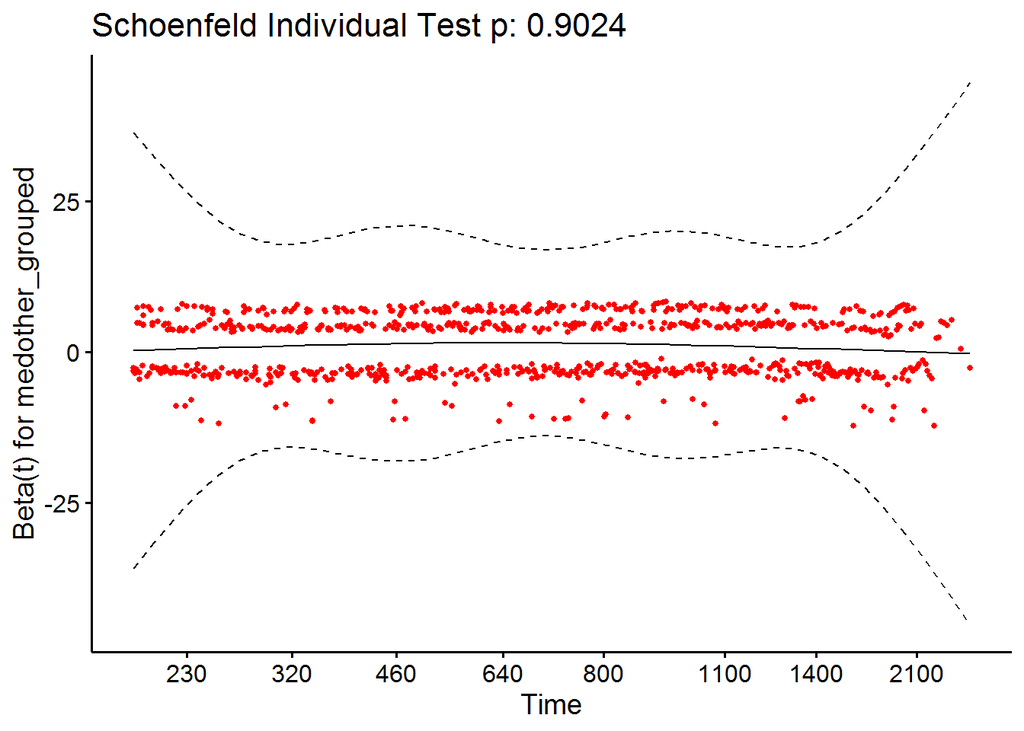

```r
anova(cox_m14)
```

```
## Analysis of Deviance Table
##  Cox model: response is Surv(time1, time2, event_death)
## Terms added sequentially (first to last)
##
##                   loglik   Chisq Df Pr(>|Chi|)
## NULL             -5075.4
## Gender_Value     -5069.3  12.187  1  0.0004814 ***
## age_obsv         -4973.0 192.533  1  < 2.2e-16 ***
## medother_grouped -4956.3  33.361  6  8.934e-06 ***
## ---
## Signif. codes:  0 '***' 0.001 '**' 0.01 '*' 0.05 '.' 0.1 ' ' 1
```

*Forest plot*

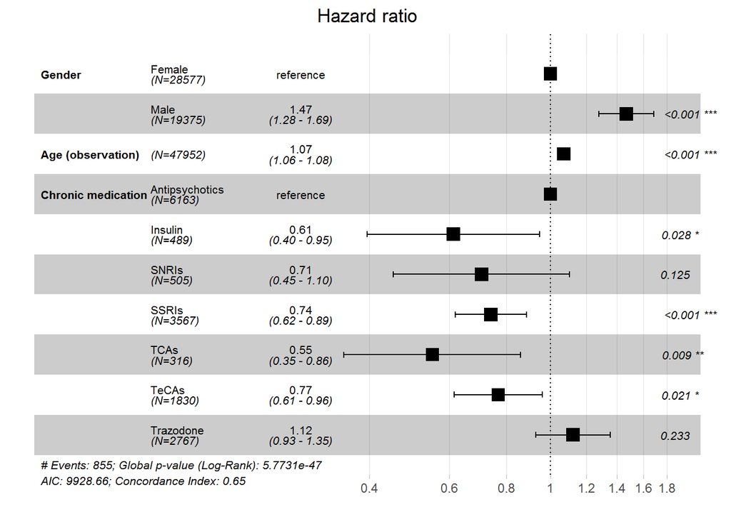

```r
forest_df14 <- all_df %>%
  transmute(time1,
            time2,
            event_death,
            Gender = factor(Gender_Value),
            `Age (observation)` = age_obsv,
            `Chronic medication` = medother_grouped) %>%
  mutate(Gender = relevel(Gender, ref = "Female"))

new14 <- coxph(Surv(time1, time2, event_death) ~ Gender + `Age (observation)` + `Chronic medication`, data = forest_df14)

ggforest(new14,
         cpositions = c(0.01, 0.175, 0.4))
```

**Gender, age at observation, marital status, and score in cognitive assessment**

```r
cox_m15 <- coxph(Surv(time1, time2, event_death) ~ Gender_Value + age_obsv + marital_status + numerator, data = all_df)

summary(cox_m15)
```

```
## Call:
## coxph(formula = Surv(time1, time2, event_death) ~ Gender_Value +
##     age_obsv + marital_status + numerator, data = all_df)
##
##   n= 12329, number of events= 826
##    (35623 observations deleted due to missingness)
##
##                                       coef exp(coef)  se(coef)      z Pr(>|z|)
## Gender_ValueMale                  0.238840  1.269776  0.076657  3.116  0.00184
## age_obsv                          0.081231  1.084622  0.005770 14.077  < 2e-16
## marital_statusDivorced/Separated  0.355400  1.426751  0.180081  1.974  0.04843
## marital_statusSingle              0.398608  1.489750  0.132349  3.012  0.00260
## marital_statusWidowed             0.174192  1.190284  0.083646  2.082  0.03730
## numerator                        -0.041820  0.959042  0.005093 -8.211  < 2e-16
##
## Gender_ValueMale                 **
## age_obsv                         ***
## marital_statusDivorced/Separated *
## marital_statusSingle             **
## marital_statusWidowed            *
## numerator                        ***
## ---
## Signif. codes:  0 '***' 0.001 '**' 0.01 '*' 0.05 '.' 0.1 ' ' 1
##
##                                  exp(coef) exp(-coef) lower .95 upper .95
## Gender_ValueMale                     1.270     0.7875    1.0926    1.4756
## age_obsv                             1.085     0.9220    1.0724    1.0970
## marital_statusDivorced/Separated     1.427     0.7009    1.0025    2.0306
## marital_statusSingle                 1.490     0.6713    1.1494    1.9309
## marital_statusWidowed                1.190     0.8401    1.0103    1.4023
## numerator                            0.959     1.0427    0.9495    0.9687
##
## Concordance= 0.679  (se = 0.011 )
## Likelihood ratio test= 349.9  on 6 df,   p=<2e-16
## Wald test            = 322  on 6 df,   p=<2e-16
## Score (logrank) test = 330.6  on 6 df,   p=<2e-16
```

```r
cox.zph(cox_m15)
```

```
##                chisq df    p
## Gender_Value   0.656  1 0.42
## age_obsv       0.674  1 0.41
## marital_status 2.048  3 0.56
## numerator      1.214  1 0.27
## GLOBAL         5.586  6 0.47
```

```r
resm15 <- cox.zph(cox_m15)

ggcoxzph(resm15)[1]
```

```
## $`1`
```

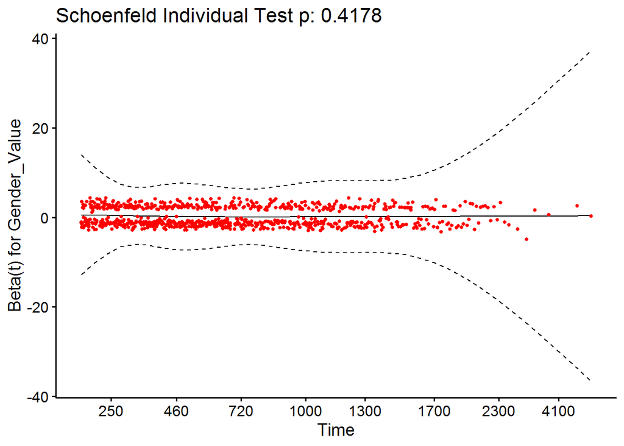

```r
ggcoxzph(resm15)[2]
```

```
## $`2`
```

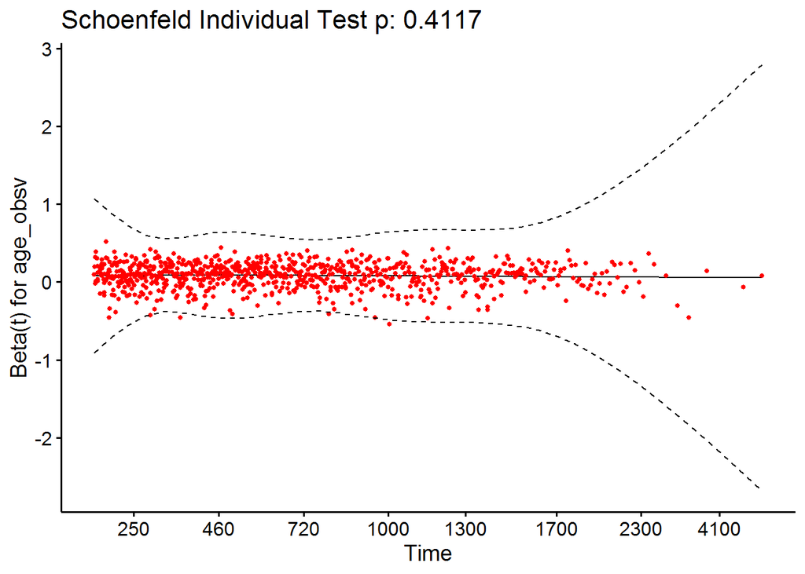

```r
ggcoxzph(resm15)[3]
```

```
## $`3`
```

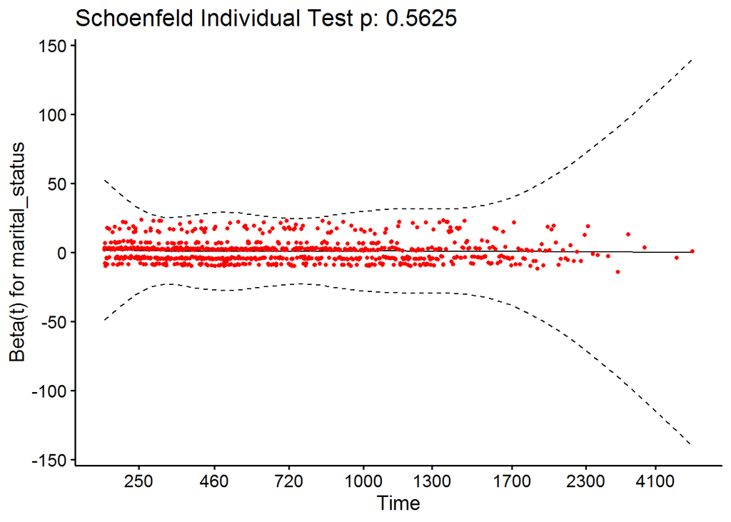

```r
ggcoxzph(resm15)[4]
```

```
## $`4`
```

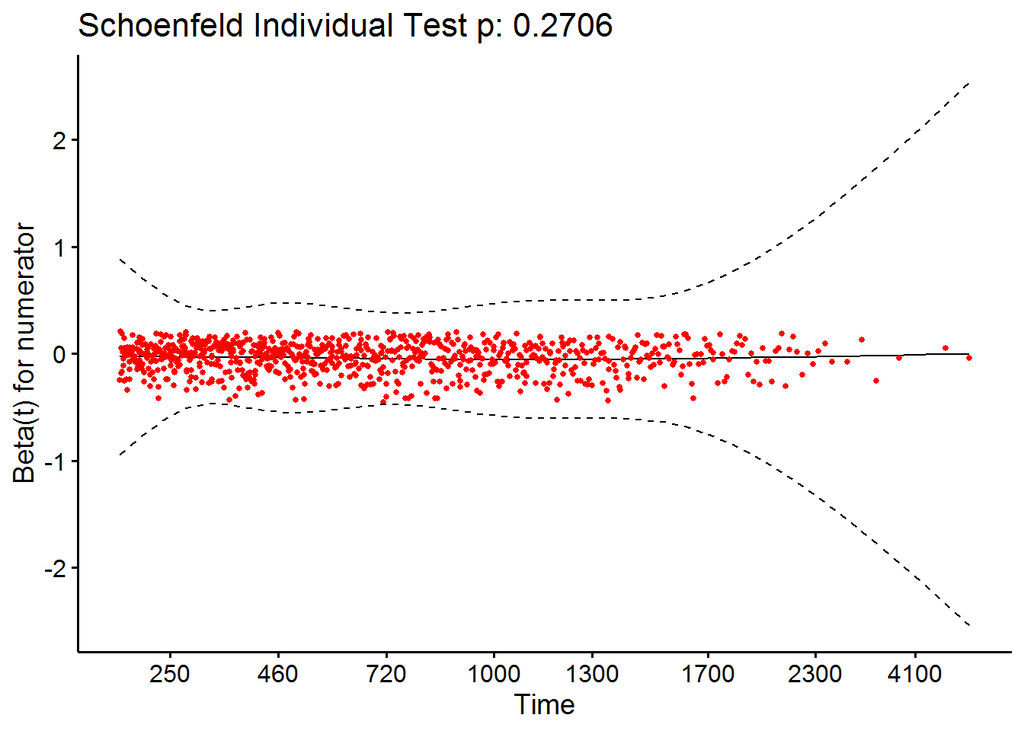

```r
anova(cox_m15)
```

```
## Analysis of Deviance Table
##  Cox model: response is Surv(time1, time2, event_death)
## Terms added sequentially (first to last)
##
##                 loglik    Chisq Df Pr(>|Chi|)
## NULL           -5461.2
## Gender_Value   -5461.2   0.0867  1    0.76842
## age_obsv       -5322.9 276.4920  1  < 2.2e-16 ***
## marital_status -5317.9   9.9743  3    0.01879 *
## numerator      -5286.2  63.3980  1  1.689e-15 ***
## ---
## Signif. codes:  0 '***' 0.001 '**' 0.01 '*' 0.05 '.' 0.1 ' ' 1
```

*Forest plot*

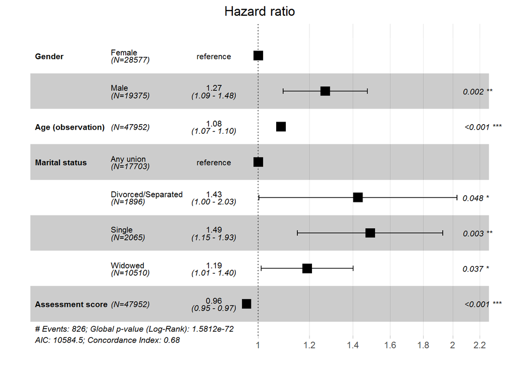

```r
forest_df15 <- all_df %>%
  transmute(time1,
            time2,
            event_death,
            Gender = factor(Gender_Value),
            `Age (observation)` = age_obsv,
            `Marital status` = marital_status,
            `Assessment score` = numerator) %>%
  mutate(Gender = relevel(Gender, ref = "Female"))

new15 <- coxph(Surv(time1, time2, event_death) ~ Gender + `Age (observation)` + `Marital status` + `Assessment score`, data = forest_df15)

ggforest(new15,
         cpositions = c(0.01, 0.175, 0.4))
```

**Gender, age at observation, marital status, and chronic medication use**

```r
cox_m16 <- coxph(Surv(time1, time2, event_death) ~  Gender_Value + age_obsv + marital_status + medother_grouped, data = all_df)

summary(cox_m16)
```

```
## Call:
## coxph(formula = Surv(time1, time2, event_death) ~ Gender_Value +
##     age_obsv + marital_status + medother_grouped, data = all_df)
##
##   n= 10209, number of events= 539
##    (37743 observations deleted due to missingness)
##
##                                      coef exp(coef) se(coef)      z Pr(>|z|)
## Gender_ValueMale                  0.36173   1.43580  0.09423  3.839 0.000124
## age_obsv                          0.06408   1.06618  0.00685  9.355  < 2e-16
## marital_statusDivorced/Separated -0.13715   0.87184  0.22950 -0.598 0.550117
## marital_statusSingle              0.13387   1.14325  0.17738  0.755 0.450408
## marital_statusWidowed             0.01921   1.01940  0.10315  0.186 0.852252
## medother_groupedInsulin          -0.41946   0.65740  0.29113 -1.441 0.149646
## medother_groupedSNRIs            -0.25539   0.77461  0.31425 -0.813 0.416392
## medother_groupedSSRIs            -0.20935   0.81111  0.12025 -1.741 0.081693
## medother_groupedTCAs             -0.68127   0.50598  0.29156 -2.337 0.019461
## medother_groupedTeCAs            -0.17068   0.84309  0.14406 -1.185 0.236106
## medother_groupedTrazodone         0.27662   1.31867  0.11975  2.310 0.020885
##
## Gender_ValueMale                 ***
## age_obsv                         ***
## marital_statusDivorced/Separated
## marital_statusSingle
## marital_statusWidowed
## medother_groupedInsulin
## medother_groupedSNRIs
## medother_groupedSSRIs            .
## medother_groupedTCAs             *
## medother_groupedTeCAs
## medother_groupedTrazodone        *
## ---
## Signif. codes:  0 '***' 0.001 '**' 0.01 '*' 0.05 '.' 0.1 ' ' 1
##
##                                  exp(coef) exp(-coef) lower .95 upper .95
## Gender_ValueMale                    1.4358     0.6965    1.1937     1.727
## age_obsv                            1.0662     0.9379    1.0520     1.081
## marital_statusDivorced/Separated    0.8718     1.1470    0.5560     1.367
## marital_statusSingle                1.1432     0.8747    0.8075     1.619
## marital_statusWidowed               1.0194     0.9810    0.8328     1.248
## medother_groupedInsulin             0.6574     1.5211    0.3716     1.163
## medother_groupedSNRIs               0.7746     1.2910    0.4184     1.434
## medother_groupedSSRIs               0.8111     1.2329    0.6408     1.027
## medother_groupedTCAs                0.5060     1.9764    0.2857     0.896
## medother_groupedTeCAs               0.8431     1.1861    0.6357     1.118
## medother_groupedTrazodone           1.3187     0.7583    1.0428     1.667
##
## Concordance= 0.657  (se = 0.014 )
## Likelihood ratio test= 154.3  on 11 df,   p=<2e-16
## Wald test            = 146.3  on 11 df,   p=<2e-16
## Score (logrank) test = 149.7  on 11 df,   p=<2e-16
```

```r
cox.zph(cox_m16)
```

```
##                   chisq df    p
## Gender_Value     0.4670  1 0.49
## age_obsv         0.0881  1 0.77
## marital_status   0.3454  3 0.95
## medother_grouped 5.1350  6 0.53
## GLOBAL           5.8854 11 0.88
```

```r
resm16 <- cox.zph(cox_m16)

ggcoxzph(resm16)[1]
```

```
## $`1`
```

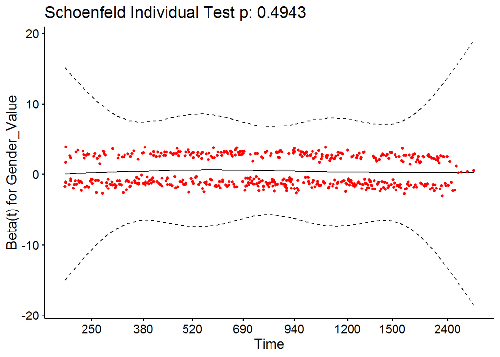

```r
ggcoxzph(resm16)[2]
```

```
## $`2`
```

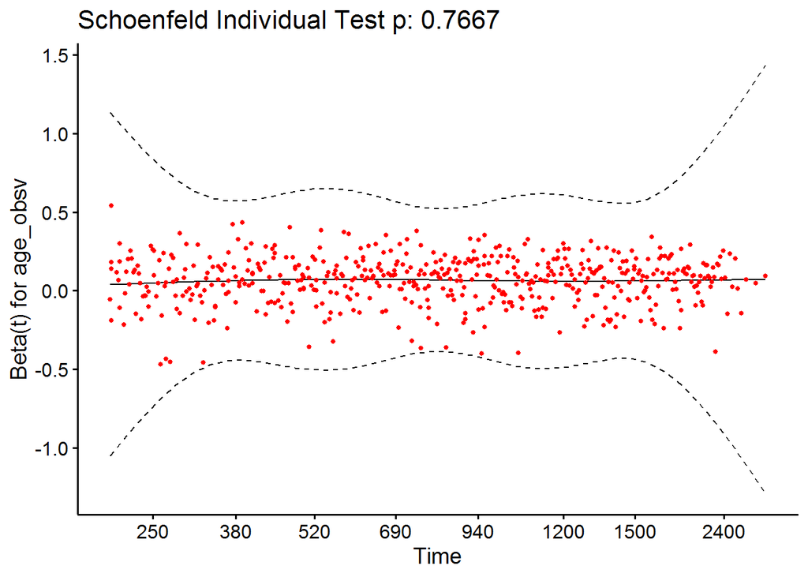

```r
ggcoxzph(resm16)[3]
```

```
## $`3`
```

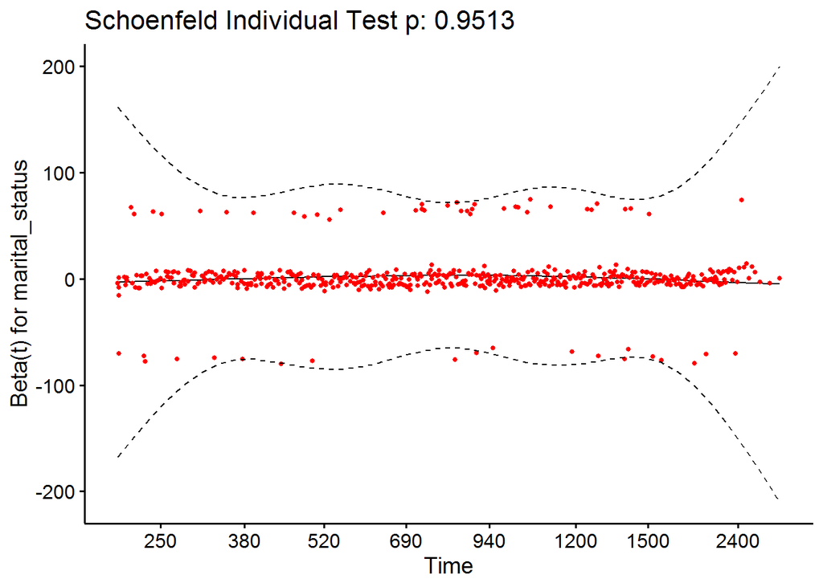

```r
ggcoxzph(resm16)[4]
```

```
## $`4`
```

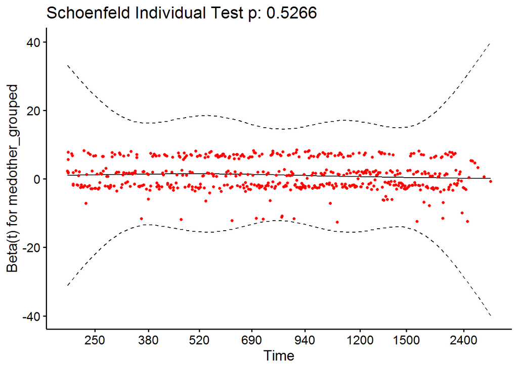

```r
anova(cox_m16)
```

```
## Analysis of Deviance Table
##  Cox model: response is Surv(time1, time2, event_death)
## Terms added sequentially (first to last)
##
##                   loglik    Chisq Df Pr(>|Chi|)
## NULL             -2950.6
## Gender_Value     -2946.4   8.4291  1  0.0036926 **
## age_obsv         -2888.0 116.8818  1  < 2.2e-16 ***
## marital_status   -2887.2   1.4807  3  0.6867212
## medother_grouped -2873.5  27.5264  6  0.0001154 ***
## ---
## Signif. codes:  0 '***' 0.001 '**' 0.01 '*' 0.05 '.' 0.1 ' ' 1
```

If remove marital status, we’re back to Gender, age at observation, and chronic medication (i.e., cox_m14)…

But we could try: **Age at observation, chronic medication, and marital_status**

```r
cox_m16a <- coxph(Surv(time1, time2, event_death) ~ age_obsv + marital_status + medother_grouped, data = all_df)

summary(cox_m16a)
```

```
## Call:
## coxph(formula = Surv(time1, time2, event_death) ~ age_obsv +
##     marital_status + medother_grouped, data = all_df)
##
##   n= 10209, number of events= 539
##    (37743 observations deleted due to missingness)
##
##                                       coef exp(coef)  se(coef)      z Pr(>|z|)
## age_obsv                          0.061736  1.063681  0.006767  9.124   <2e-16
## marital_statusDivorced/Separated -0.228063  0.796074  0.228333 -0.999   0.3179
## marital_statusSingle              0.098141  1.103119  0.177259  0.554   0.5798
## marital_statusWidowed            -0.089953  0.913974  0.099082 -0.908   0.3639
## medother_groupedInsulin          -0.402231  0.668826  0.291067 -1.382   0.1670
## medother_groupedSNRIs            -0.264350  0.767705  0.314240 -0.841   0.4002
## medother_groupedSSRIs            -0.228744  0.795532  0.120019 -1.906   0.0567
## medother_groupedTCAs             -0.741652  0.476326  0.291057 -2.548   0.0108
## medother_groupedTeCAs            -0.169934  0.843721  0.143890 -1.181   0.2376
## medother_groupedTrazodone         0.294128  1.341956  0.119463  2.462   0.0138
##
## age_obsv                         ***
## marital_statusDivorced/Separated
## marital_statusSingle
## marital_statusWidowed
## medother_groupedInsulin
## medother_groupedSNRIs
## medother_groupedSSRIs            .
## medother_groupedTCAs             *
## medother_groupedTeCAs
## medother_groupedTrazodone        *
## ---
## Signif. codes:  0 '***' 0.001 '**' 0.01 '*' 0.05 '.' 0.1 ' ' 1
##
##                                  exp(coef) exp(-coef) lower .95 upper .95
## age_obsv                            1.0637     0.9401    1.0497    1.0779
## marital_statusDivorced/Separated    0.7961     1.2562    0.5089    1.2454
## marital_statusSingle                1.1031     0.9065    0.7794    1.5614
## marital_statusWidowed               0.9140     1.0941    0.7527    1.1099
## medother_groupedInsulin             0.6688     1.4952    0.3781    1.1832
## medother_groupedSNRIs               0.7677     1.3026    0.4147    1.4213
## medother_groupedSSRIs               0.7955     1.2570    0.6288    1.0065
## medother_groupedTCAs                0.4763     2.0994    0.2693    0.8427
## medother_groupedTeCAs               0.8437     1.1852    0.6364    1.1186
## medother_groupedTrazodone           1.3420     0.7452    1.0618    1.6960
##
## Concordance= 0.649  (se = 0.014 )
## Likelihood ratio test= 139.8  on 10 df,   p=<2e-16
## Wald test            = 134.4  on 10 df,   p=<2e-16
## Score (logrank) test = 137.5  on 10 df,   p=<2e-16
```

```r
cox.zph(cox_m16a)
```

```
##                  chisq df    p
## age_obsv          0.18  1 0.67
## marital_status    0.48  3 0.92
## medother_grouped  4.69  6 0.58
## GLOBAL            5.62 10 0.85
```

```r
resm16a <- cox.zph(cox_m16a)

ggcoxzph(resm16a)[1]
```

```
## $`1`
```

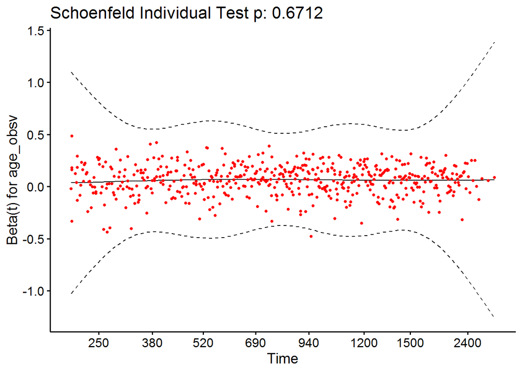

```r
ggcoxzph(resm16a)[2]
```

```
## $`2`
```

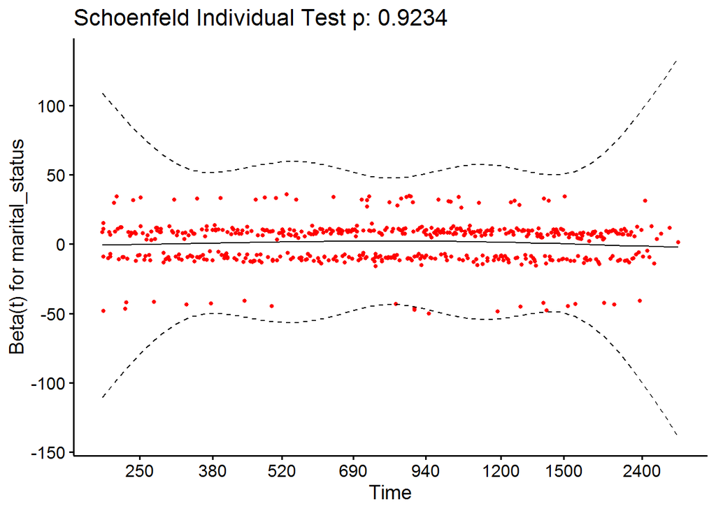

```r
ggcoxzph(resm16a)[3]
```

```
## $`3`
```

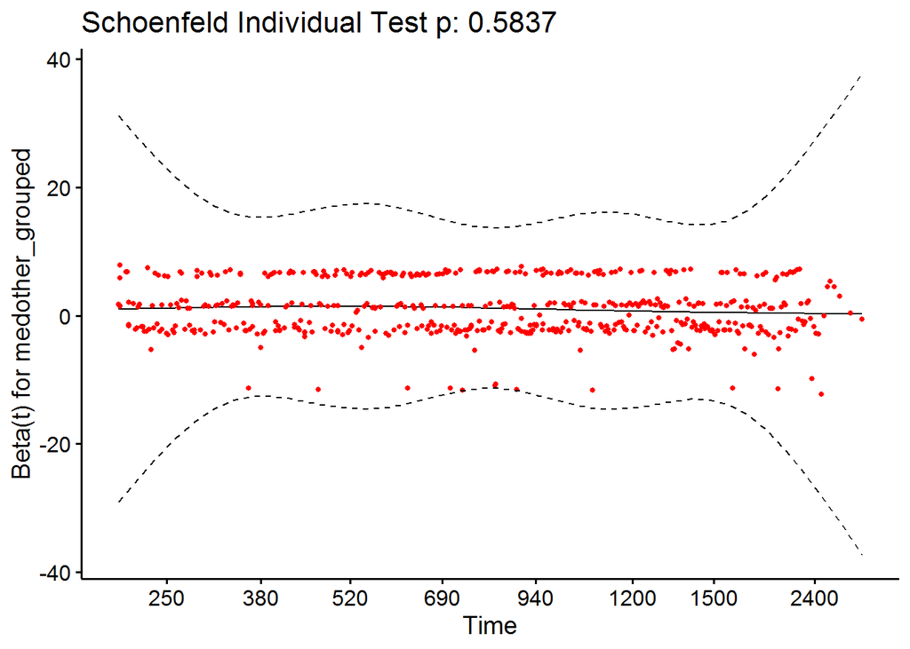

```r
anova(cox_m16a)
```

```
## Analysis of Deviance Table
##  Cox model: response is Surv(time1, time2, event_death)
## Terms added sequentially (first to last)
##
##                   loglik    Chisq Df Pr(>|Chi|)
## NULL             -2950.6
## age_obsv         -2898.1 105.0890  1  < 2.2e-16 ***
## marital_status   -2896.4   3.3092  3     0.3464
## medother_grouped -2880.7  31.3772  6  2.147e-05 ***
## ---
## Signif. codes:  0 '***' 0.001 '**' 0.01 '*' 0.05 '.' 0.1 ' ' 1
```

We removed marital status because it was not a significant covariate in model

**Age at observation and chronic medication**

```r
cox_m16b <- coxph(Surv(time1, time2, event_death) ~ age_obsv + medother_grouped, data = all_df)

summary(cox_m16b)
```

```
## Call:
## coxph(formula = Surv(time1, time2, event_death) ~ age_obsv +
##     medother_grouped, data = all_df)
##
##   n= 15637, number of events= 855
##    (32315 observations deleted due to missingness)
##
##                                coef exp(coef)  se(coef)      z Pr(>|z|)
## age_obsv                   0.061836  1.063788  0.004953 12.485  < 2e-16 ***
## medother_groupedInsulin   -0.498558  0.607406  0.222651 -2.239 0.025143 *
## medother_groupedSNRIs     -0.357732  0.699260  0.227490 -1.573 0.115830
## medother_groupedSSRIs     -0.307369  0.735380  0.091565 -3.357 0.000788 ***
## medother_groupedTCAs      -0.668437  0.512509  0.227698 -2.936 0.003329 **
## medother_groupedTeCAs     -0.261850  0.769627  0.113985 -2.297 0.021605 *
## medother_groupedTrazodone  0.135750  1.145395  0.095524  1.421 0.155285
## ---
## Signif. codes:  0 '***' 0.001 '**' 0.01 '*' 0.05 '.' 0.1 ' ' 1
##
##                           exp(coef) exp(-coef) lower .95 upper .95
## age_obsv                     1.0638     0.9400    1.0535    1.0742
## medother_groupedInsulin      0.6074     1.6463    0.3926    0.9397
## medother_groupedSNRIs        0.6993     1.4301    0.4477    1.0921
## medother_groupedSSRIs        0.7354     1.3598    0.6146    0.8799
## medother_groupedTCAs         0.5125     1.9512    0.3280    0.8008
## medother_groupedTeCAs        0.7696     1.2993    0.6155    0.9623
## medother_groupedTrazodone    1.1454     0.8731    0.9498    1.3812
##
## Concordance= 0.645  (se = 0.011 )
## Likelihood ratio test= 209.8  on 7 df,   p=<2e-16
## Wald test            = 202.4  on 7 df,   p=<2e-16
## Score (logrank) test = 205.6  on 7 df,   p=<2e-16
```

```r
cox.zph(cox_m16b)
```

```
##                  chisq df    p
## age_obsv         0.144  1 0.70
## medother_grouped 2.541  6 0.86
## GLOBAL           2.643  7 0.92
```

```r
resm16b <- cox.zph(cox_m16b)

ggcoxzph(resm16b)[1]
```

```
## $`1`
```

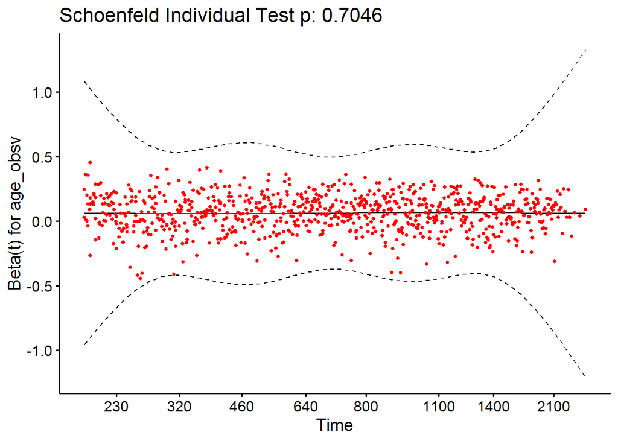

```r
ggcoxzph(resm16b)[2]
```

```
## $`2`
```

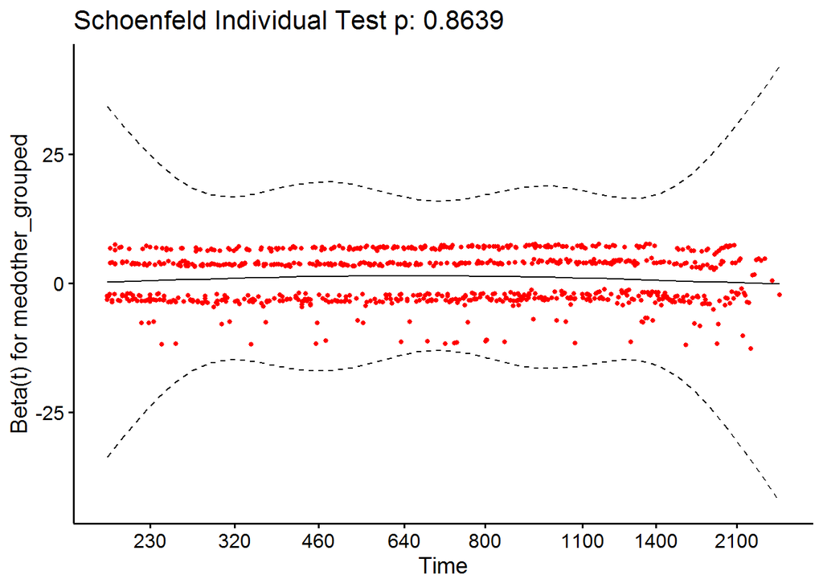

```r
anova(cox_m16b)
```

```
## Analysis of Deviance Table
##  Cox model: response is Surv(time1, time2, event_death)
## Terms added sequentially (first to last)
##
##                   loglik   Chisq Df Pr(>|Chi|)
## NULL             -5075.4
## age_obsv         -4989.5 171.764  1  < 2.2e-16 ***
## medother_grouped -4970.5  38.009  6  1.119e-06 ***
## ---
## Signif. codes:  0 '***' 0.001 '**' 0.01 '*' 0.05 '.' 0.1 ' ' 1
```

*Forest plot*

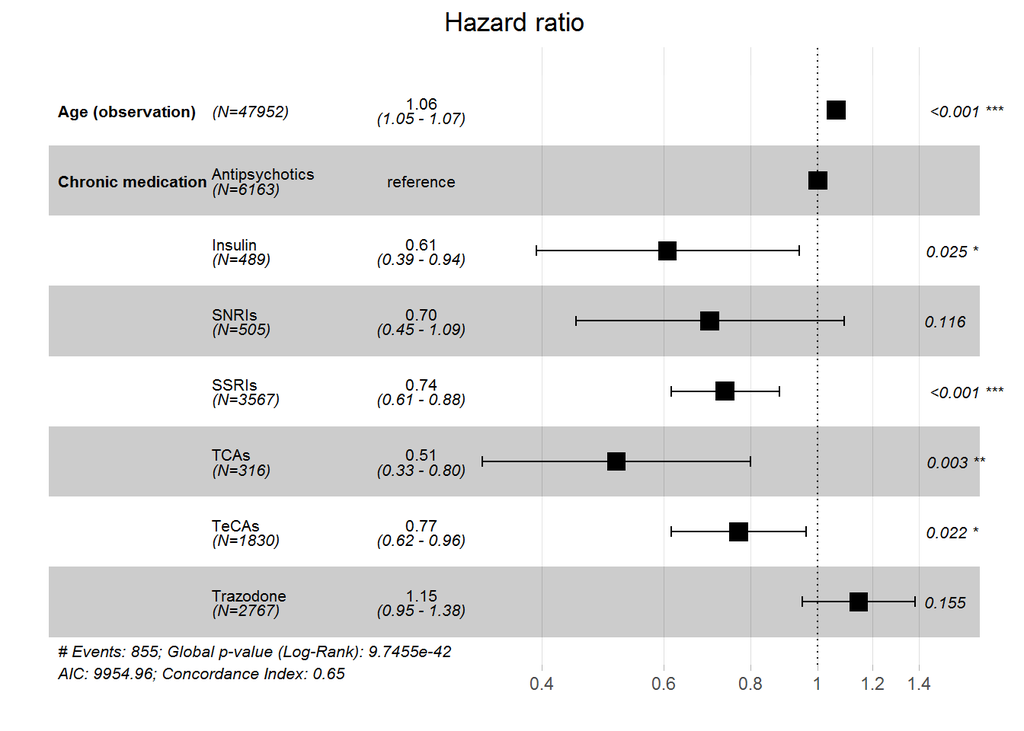

```r
forest_df16b <- all_df %>%
  transmute(time1,
            time2,
            event_death,
            `Age (observation)` = age_obsv,
            `Chronic medication` = medother_grouped)

new16b <- coxph(Surv(time1, time2, event_death) ~  `Age (observation)` + `Chronic medication`, data = forest_df16b)

ggforest(new16b,
         cpositions = c(0.01, 0.175, 0.4))
```

**Gender, age at observation, cognitive assessment score, and chronic medication**

```r
cox_m17 <- coxph(Surv(time1, time2, event_death) ~  Gender_Value + age_obsv + numerator + medother_grouped, data = all_df)

summary(cox_m17)
```

```
## Call:
## coxph(formula = Surv(time1, time2, event_death) ~ Gender_Value +
##     age_obsv + numerator + medother_grouped, data = all_df)
##
##   n= 3760, number of events= 169
##    (44192 observations deleted due to missingness)
##
##                               coef exp(coef) se(coef)      z Pr(>|z|)
## Gender_ValueMale           0.13259   1.14178  0.16565  0.800   0.4234
## age_obsv                   0.09742   1.10232  0.01274  7.645 2.10e-14 ***
## numerator                 -0.07397   0.92870  0.01154 -6.407 1.48e-10 ***
## medother_groupedInsulin   -0.31976   0.72633  0.48957 -0.653   0.5137
## medother_groupedSNRIs     -0.08796   0.91580  0.49421 -0.178   0.8587
## medother_groupedSSRIs     -0.29461   0.74482  0.22545 -1.307   0.1913
## medother_groupedTCAs      -0.68754   0.50281  0.36102 -1.904   0.0569 .
## medother_groupedTeCAs     -0.42710   0.65240  0.28665 -1.490   0.1362
## medother_groupedTrazodone -0.15219   0.85882  0.28421 -0.535   0.5923
## ---
## Signif. codes:  0 '***' 0.001 '**' 0.01 '*' 0.05 '.' 0.1 ' ' 1
##
##                           exp(coef) exp(-coef) lower .95 upper .95
## Gender_ValueMale             1.1418     0.8758    0.8253     1.580
## age_obsv                     1.1023     0.9072    1.0751     1.130
## numerator                    0.9287     1.0768    0.9079     0.950
## medother_groupedInsulin      0.7263     1.3768    0.2782     1.896
## medother_groupedSNRIs        0.9158     1.0919    0.3476     2.413
## medother_groupedSSRIs        0.7448     1.3426    0.4788     1.159
## medother_groupedTCAs         0.5028     1.9888    0.2478     1.020
## medother_groupedTeCAs        0.6524     1.5328    0.3720     1.144
## medother_groupedTrazodone    0.8588     1.1644    0.4920     1.499
##
## Concordance= 0.736  (se = 0.022 )
## Likelihood ratio test= 109.4  on 9 df,   p=<2e-16
## Wald test            = 97.33  on 9 df,   p=<2e-16
## Score (logrank) test = 101  on 9 df,   p=<2e-16
```

```r
cox.zph(cox_m17)
```

```
##                   chisq df     p
## Gender_Value      2.197  1 0.138
## age_obsv          3.359  1 0.067
## numerator         0.295  1 0.587
## medother_grouped  2.930  6 0.818
## GLOBAL           10.592  9 0.305
```

```r
resm17 <- cox.zph(cox_m17)

ggcoxzph(resm17)[1]
```

```
## $`1`
```

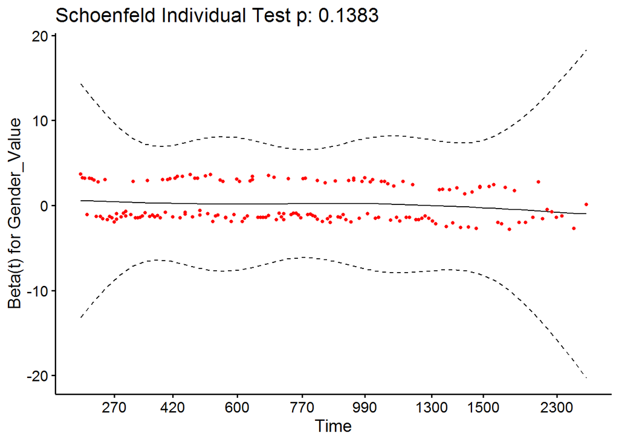

```r
ggcoxzph(resm17)[2]
```

```
## $`2`
```

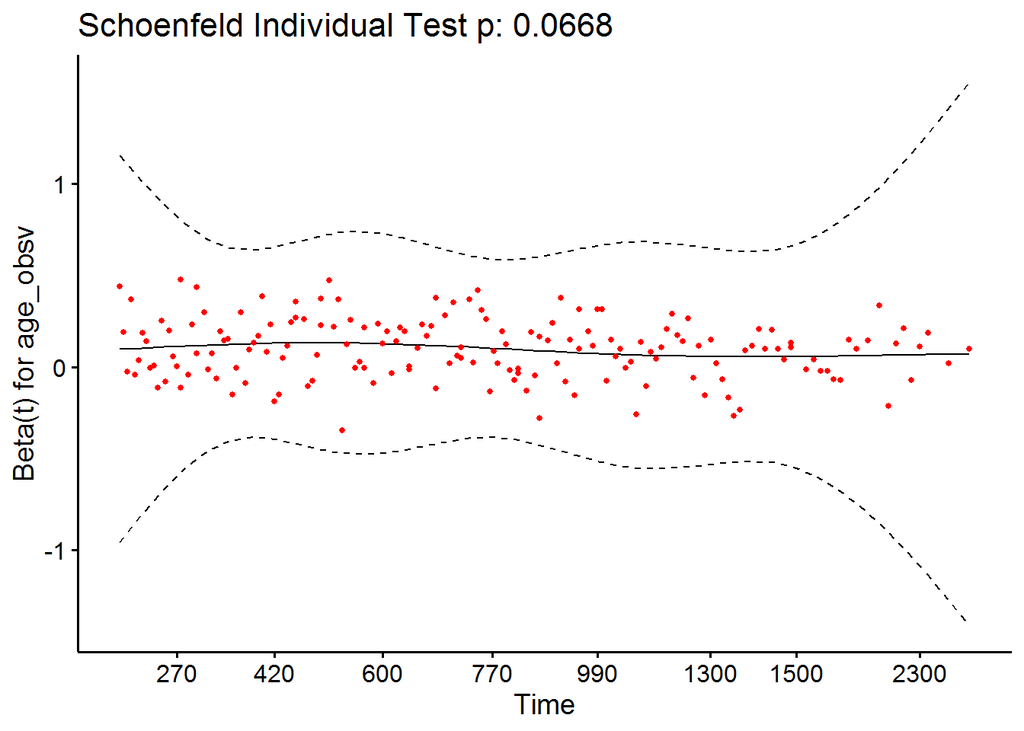

```r
ggcoxzph(resm17)[3]
```

```
## $`3`
```

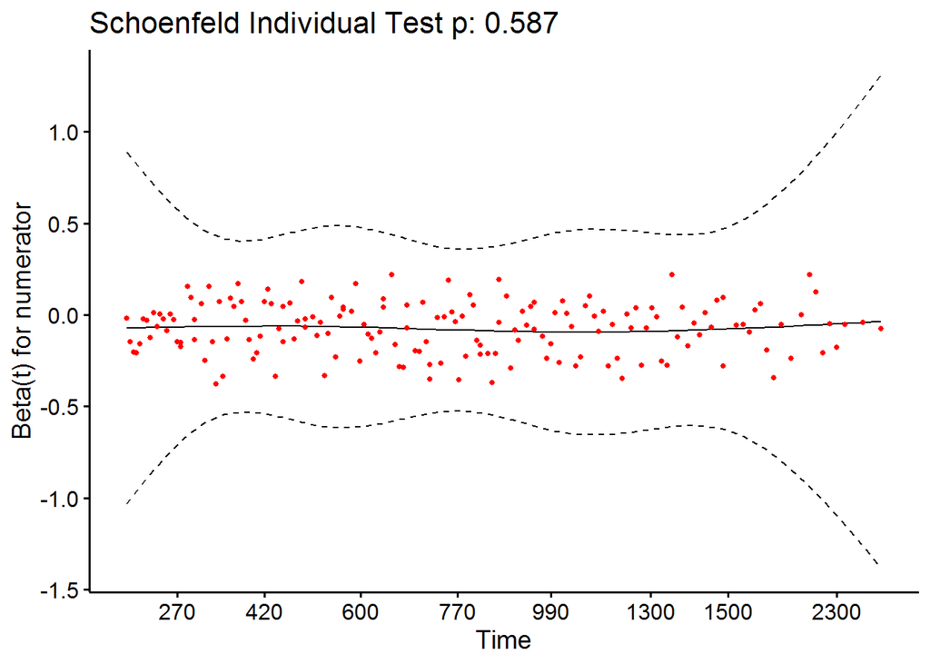

```r
ggcoxzph(resm17)[4]
```

```
## $`4`
```

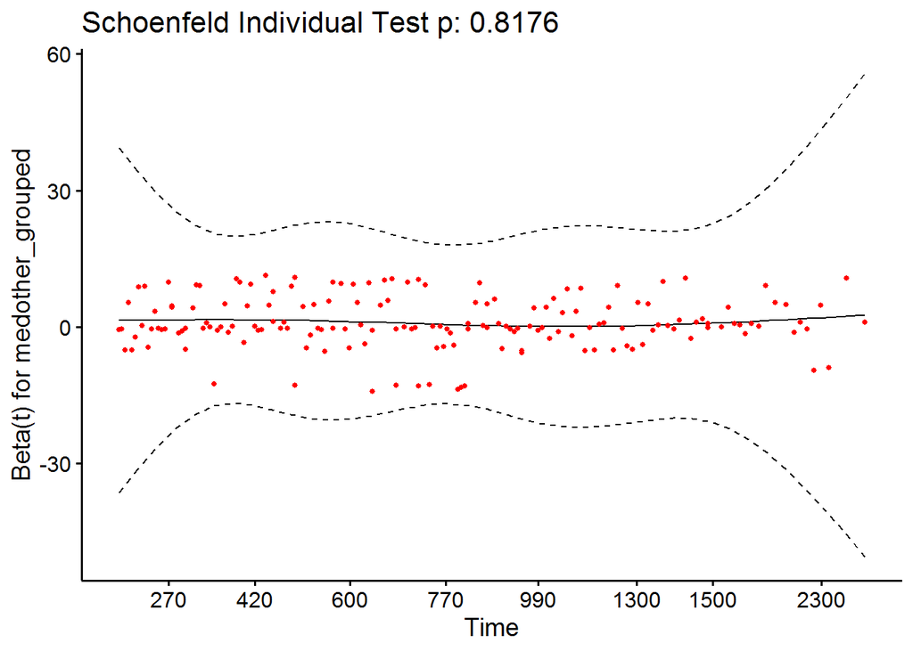

```r
anova(cox_m17)
```

```
## Analysis of Deviance Table
##  Cox model: response is Surv(time1, time2, event_death)
## Terms added sequentially (first to last)
##
##                   loglik   Chisq Df Pr(>|Chi|)
## NULL             -768.85
## Gender_Value     -768.84  0.0089  1     0.9250
## age_obsv         -736.89 63.9140  1  1.300e-15 ***
## numerator        -716.66 40.4422  1  2.025e-10 ***
## medother_grouped -714.15  5.0264  6     0.5404
## ---
## Signif. codes:  0 '***' 0.001 '**' 0.01 '*' 0.05 '.' 0.1 ' ' 1
```

We removed gender:

**Age at observation, cognitive assessment score, and chronic medication**

```r
cox_m17a <- coxph(Surv(time1, time2, event_death) ~ age_obsv + numerator + medother_grouped, data = all_df)

summary(cox_m17a)
```

```
## Call:
## coxph(formula = Surv(time1, time2, event_death) ~ age_obsv +
##     numerator + medother_grouped, data = all_df)
##
##   n= 3760, number of events= 169
##    (44192 observations deleted due to missingness)
##
##                               coef exp(coef) se(coef)      z Pr(>|z|)
## age_obsv                   0.09650   1.10131  0.01268  7.609 2.76e-14 ***
## numerator                 -0.07399   0.92868  0.01157 -6.395 1.60e-10 ***
## medother_groupedInsulin   -0.30845   0.73459  0.48942 -0.630   0.5285
## medother_groupedSNRIs     -0.06161   0.94025  0.49332 -0.125   0.9006
## medother_groupedSSRIs     -0.28880   0.74916  0.22525 -1.282   0.1998
## medother_groupedTCAs      -0.71240   0.49046  0.35956 -1.981   0.0476 *
## medother_groupedTeCAs     -0.41817   0.65825  0.28661 -1.459   0.1446
## medother_groupedTrazodone -0.13177   0.87654  0.28312 -0.465   0.6416
## ---
## Signif. codes:  0 '***' 0.001 '**' 0.01 '*' 0.05 '.' 0.1 ' ' 1
##
##                           exp(coef) exp(-coef) lower .95 upper .95
## age_obsv                     1.1013      0.908    1.0743    1.1290
## numerator                    0.9287      1.077    0.9079    0.9500
## medother_groupedInsulin      0.7346      1.361    0.2815    1.9171
## medother_groupedSNRIs        0.9403      1.064    0.3575    2.4726
## medother_groupedSSRIs        0.7492      1.335    0.4818    1.1649
## medother_groupedTCAs         0.4905      2.039    0.2424    0.9924
## medother_groupedTeCAs        0.6582      1.519    0.3753    1.1544
## medother_groupedTrazodone    0.8765      1.141    0.5032    1.5267
##
## Concordance= 0.734  (se = 0.022 )
## Likelihood ratio test= 108.8  on 8 df,   p=<2e-16
## Wald test            = 96.51  on 8 df,   p=<2e-16
## Score (logrank) test = 99.89  on 8 df,   p=<2e-16
```

```r
cox.zph(cox_m17a)
```

```
##                  chisq df     p
## age_obsv         3.269  1 0.071
## numerator        0.372  1 0.542
## medother_grouped 3.162  6 0.788
## GLOBAL           6.926  8 0.545
```

```r
resm17a <- cox.zph(cox_m17a)

ggcoxzph(resm17a)[1]
```

```
## $`1`
```

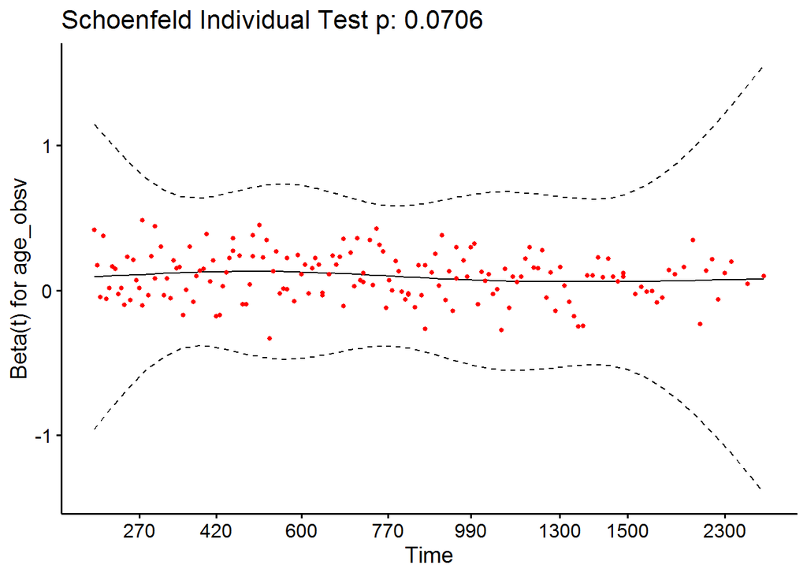

```r
ggcoxzph(resm17a)[2]
```

```
## $`2`
```

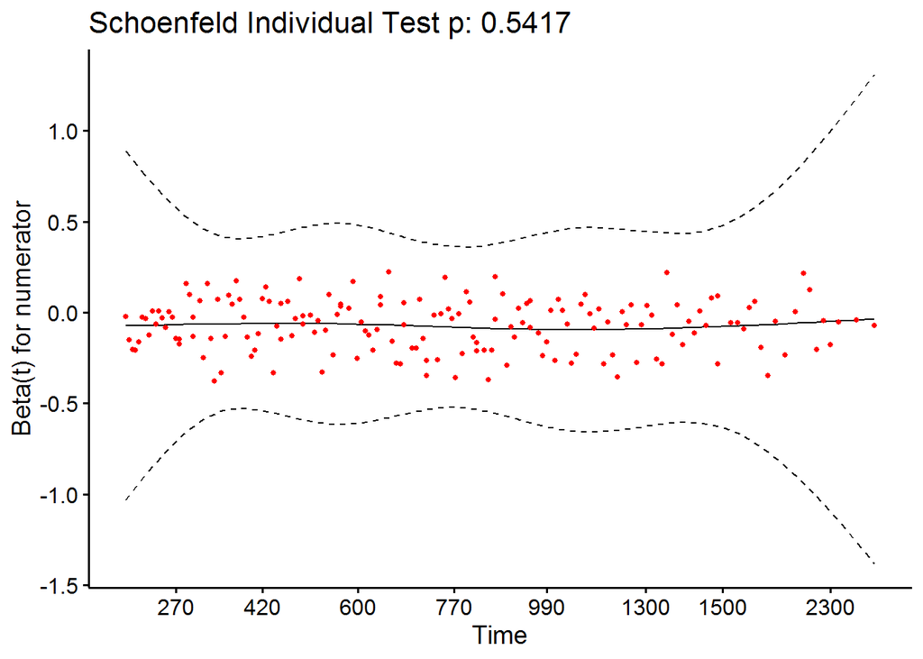

```r
ggcoxzph(resm17a)[3]
```

```
## $`3`
```

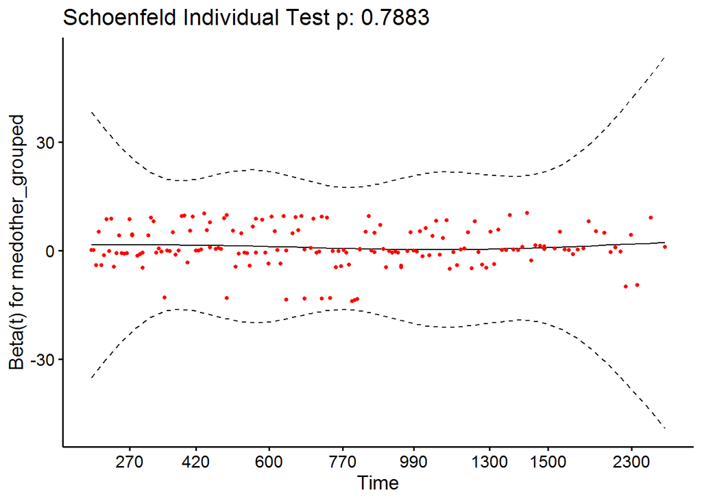

```r
anova(cox_m17a)
```

```
## Analysis of Deviance Table
##  Cox model: response is Surv(time1, time2, event_death)
## Terms added sequentially (first to last)
##
##                   loglik   Chisq Df Pr(>|Chi|)
## NULL             -768.85
## age_obsv         -737.46 62.7715  1  2.321e-15 ***
## numerator        -717.19 40.5442  1  1.922e-10 ***
## medother_grouped -714.47  5.4421  6     0.4885
## ---
## Signif. codes:  0 '***' 0.001 '**' 0.01 '*' 0.05 '.' 0.1 ' ' 1
```

*Forest plot*

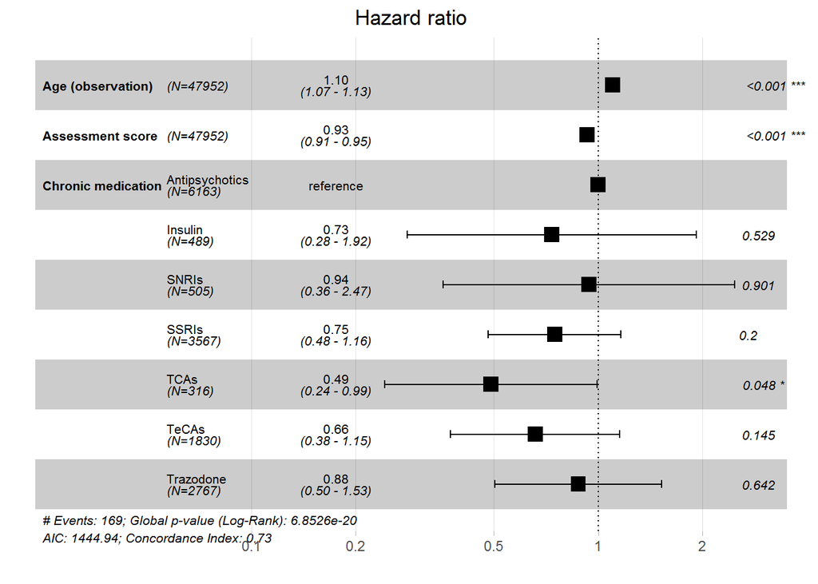

```r
forest_df17a <- all_df %>%
  transmute(time1,
            time2,
            event_death,
            `Age (observation)` = age_obsv,
            `Assessment score` = numerator,
            `Chronic medication` = medother_grouped)

new17a <- coxph(Surv(time1, time2, event_death) ~  `Age (observation)` + `Assessment score` + `Chronic medication`, data = forest_df17a)

ggforest(new17a,
         cpositions = c(0.01, 0.175, 0.4))
```

**Gender, age at observation, marital status, cognitive assessment score, and chronic medication**

```r
cox_m18 <- coxph(Surv(time1, time2, event_death) ~  Gender_Value + age_obsv + marital_status + numerator + medother_grouped, data = all_df)

summary(cox_m18)
```

```
## Call:
## coxph(formula = Surv(time1, time2, event_death) ~ Gender_Value +
##     age_obsv + marital_status + numerator + medother_grouped,
##     data = all_df)
##
##   n= 2447, number of events= 104
##    (45505 observations deleted due to missingness)
##
##                                      coef exp(coef) se(coef)      z Pr(>|z|)
## Gender_ValueMale                 -0.32012   0.72606  0.23220 -1.379   0.1680
## age_obsv                          0.08228   1.08576  0.01728  4.760 1.93e-06
## marital_statusDivorced/Separated -0.10738   0.89818  0.61788 -0.174   0.8620
## marital_statusSingle              0.11416   1.12093  0.49553  0.230   0.8178
## marital_statusWidowed             0.30203   1.35260  0.24360  1.240   0.2150
## numerator                        -0.07341   0.92922  0.01541 -4.765 1.89e-06
## medother_groupedInsulin           0.02644   1.02679  0.57817  0.046   0.9635
## medother_groupedSNRIs             0.19313   1.21304  0.66044  0.292   0.7700
## medother_groupedSSRIs            -0.21052   0.81016  0.29922 -0.704   0.4817
## medother_groupedTCAs             -0.91953   0.39871  0.47017 -1.956   0.0505
## medother_groupedTeCAs            -0.47023   0.62486  0.38488 -1.222   0.2218
## medother_groupedTrazodone        -0.01830   0.98187  0.37366 -0.049   0.9609
##
## Gender_ValueMale
## age_obsv                         ***
## marital_statusDivorced/Separated
## marital_statusSingle
## marital_statusWidowed
## numerator                        ***
## medother_groupedInsulin
## medother_groupedSNRIs
## medother_groupedSSRIs
## medother_groupedTCAs             .
## medother_groupedTeCAs
## medother_groupedTrazodone
## ---
## Signif. codes:  0 '***' 0.001 '**' 0.01 '*' 0.05 '.' 0.1 ' ' 1
##
##                                  exp(coef) exp(-coef) lower .95 upper .95
## Gender_ValueMale                    0.7261     1.3773    0.4606    1.1445
## age_obsv                            1.0858     0.9210    1.0496    1.1232
## marital_statusDivorced/Separated    0.8982     1.1134    0.2676    3.0151
## marital_statusSingle                1.1209     0.8921    0.4244    2.9606
## marital_statusWidowed               1.3526     0.7393    0.8391    2.1803
## numerator                           0.9292     1.0762    0.9016    0.9577
## medother_groupedInsulin             1.0268     0.9739    0.3306    3.1888
## medother_groupedSNRIs               1.2130     0.8244    0.3324    4.4263
## medother_groupedSSRIs               0.8102     1.2343    0.4507    1.4564
## medother_groupedTCAs                0.3987     2.5081    0.1587    1.0020
## medother_groupedTeCAs               0.6249     1.6004    0.2939    1.3286
## medother_groupedTrazodone           0.9819     1.0185    0.4721    2.0423
##
## Concordance= 0.745  (se = 0.028 )
## Likelihood ratio test= 72.42  on 12 df,   p=1e-10
## Wald test            = 64.52  on 12 df,   p=3e-09
## Score (logrank) test = 69.04  on 12 df,   p=5e-10
```

```r
cox.zph(cox_m18)
```

```
##                    chisq df     p
## Gender_Value      0.5782  1 0.447
## age_obsv          2.8065  1 0.094
## marital_status    5.0644  3 0.167
## numerator         0.0291  1 0.864
## medother_grouped  3.1473  6 0.790
## GLOBAL           10.1692 12 0.601
```

```r
resm18 <- cox.zph(cox_m18)

ggcoxzph(resm18)[1]
```

```
## $`1`
```

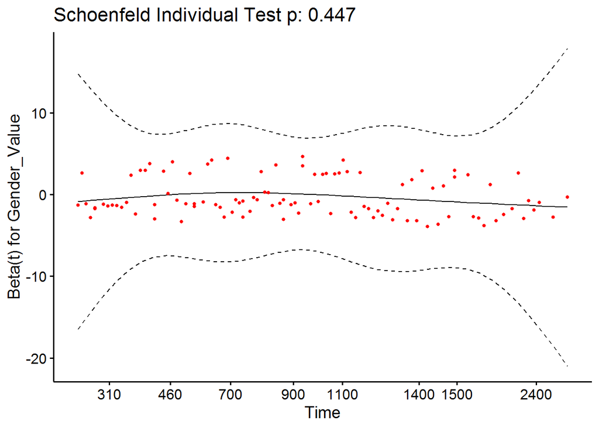

```r
ggcoxzph(resm18)[2]
```

```
## $`2`
```

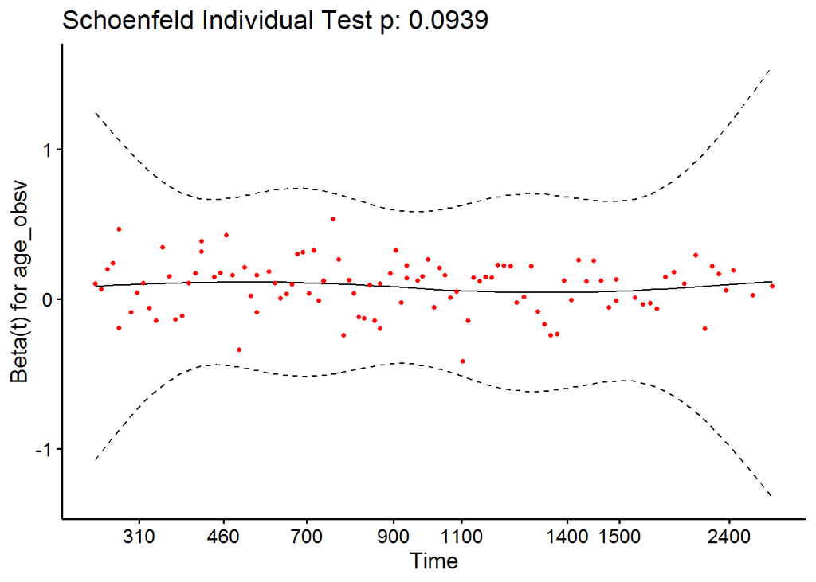

```r
ggcoxzph(resm18)[3]
```

```
## $`3`
```

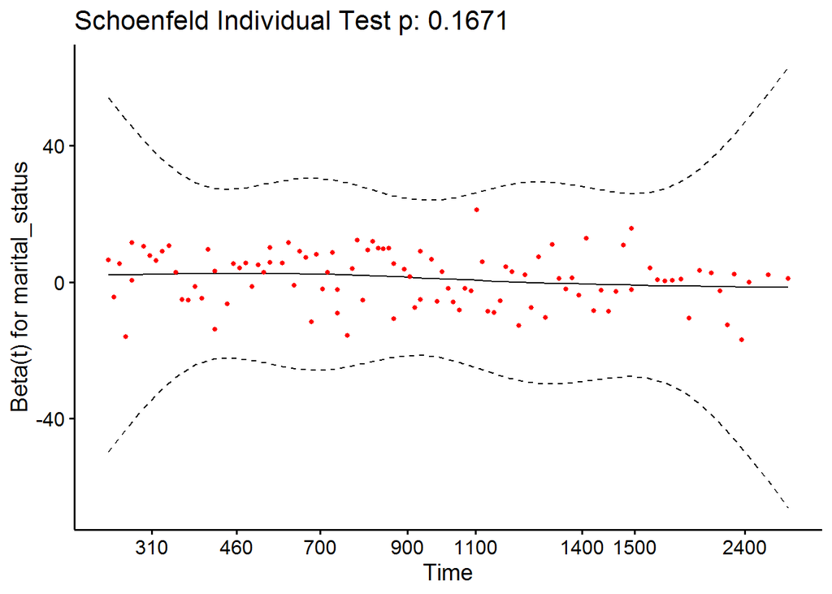

```r
ggcoxzph(resm18)[4]
```

```
## $`4`
```

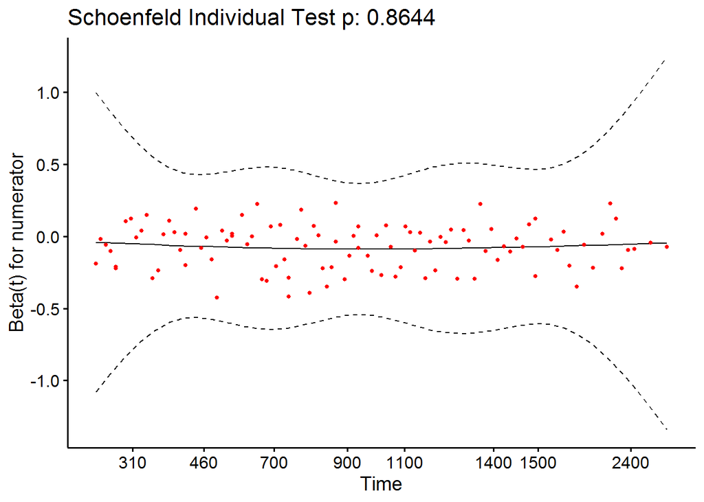

```r
ggcoxzph(resm18)[5]
```

```
## $`5`
```

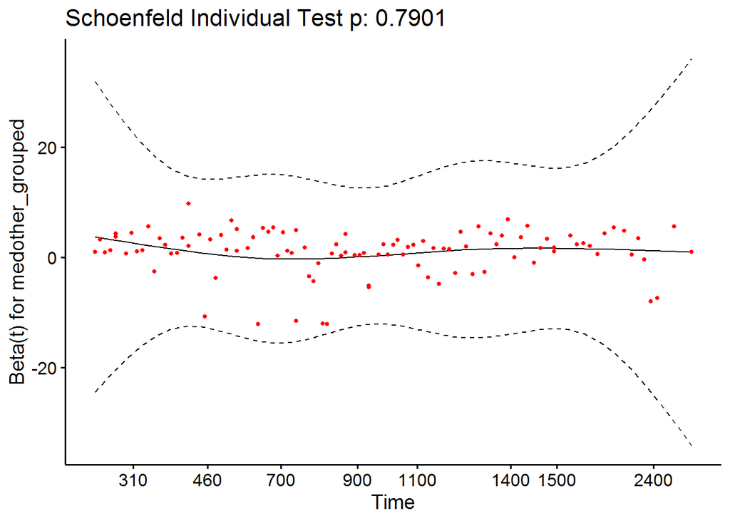

```r
anova(cox_m18)
```

```
## Analysis of Deviance Table
##  Cox model: response is Surv(time1, time2, event_death)
## Terms added sequentially (first to last)
##
##                   loglik   Chisq Df Pr(>|Chi|)
## NULL             -415.52
## Gender_Value     -413.85  3.3393  1    0.06764 .
## age_obsv         -395.96 35.7931  1  2.194e-09 ***
## marital_status   -394.73  2.4455  3    0.48522
## numerator        -382.52 24.4264  1  7.720e-07 ***
## medother_grouped -379.31  6.4176  6    0.37807
## ---
## Signif. codes:  0 '***' 0.001 '**' 0.01 '*' 0.05 '.' 0.1 ' ' 1
```

We removed gender:

**Age at observation, marital status, cognitive assessment score, and chronic medication**

```r
cox_m18a <- coxph(Surv(time1, time2, event_death) ~ age_obsv + marital_status + numerator + medother_grouped, data = all_df)

summary(cox_m18a)
```

```
## Call:
## coxph(formula = Surv(time1, time2, event_death) ~ age_obsv +
##     marital_status + numerator + medother_grouped, data = all_df)
##
##   n= 2447, number of events= 104
##    (45505 observations deleted due to missingness)
##
##                                      coef exp(coef) se(coef)      z Pr(>|z|)
## age_obsv                          0.08340   1.08698  0.01743  4.786 1.70e-06
## marital_statusDivorced/Separated -0.04471   0.95627  0.61726 -0.072   0.9423
## marital_statusSingle              0.15783   1.17097  0.49127  0.321   0.7480
## marital_statusWidowed             0.38322   1.46700  0.23686  1.618   0.1057
## numerator                        -0.07242   0.93014  0.01541 -4.698 2.63e-06
## medother_groupedInsulin           0.01249   1.01256  0.57565  0.022   0.9827
## medother_groupedSNRIs             0.08762   1.09158  0.65183  0.134   0.8931
## medother_groupedSSRIs            -0.20471   0.81489  0.29956 -0.683   0.4944
## medother_groupedTCAs             -0.83178   0.43528  0.46673 -1.782   0.0747
## medother_groupedTeCAs            -0.48003   0.61876  0.38432 -1.249   0.2117
## medother_groupedTrazodone        -0.05409   0.94735  0.37320 -0.145   0.8848
##
## age_obsv                         ***
## marital_statusDivorced/Separated
## marital_statusSingle
## marital_statusWidowed
## numerator                        ***
## medother_groupedInsulin
## medother_groupedSNRIs
## medother_groupedSSRIs
## medother_groupedTCAs             .
## medother_groupedTeCAs
## medother_groupedTrazodone
## ---
## Signif. codes:  0 '***' 0.001 '**' 0.01 '*' 0.05 '.' 0.1 ' ' 1
##
##                                  exp(coef) exp(-coef) lower .95 upper .95
## age_obsv                            1.0870     0.9200    1.0505    1.1247
## marital_statusDivorced/Separated    0.9563     1.0457    0.2852    3.2063
## marital_statusSingle                1.1710     0.8540    0.4471    3.0670
## marital_statusWidowed               1.4670     0.6817    0.9222    2.3337
## numerator                           0.9301     1.0751    0.9025    0.9587
## medother_groupedInsulin             1.0126     0.9876    0.3277    3.1291
## medother_groupedSNRIs               1.0916     0.9161    0.3042    3.9165
## medother_groupedSSRIs               0.8149     1.2272    0.4530    1.4658
## medother_groupedTCAs                0.4353     2.2974    0.1744    1.0865
## medother_groupedTeCAs               0.6188     1.6161    0.2913    1.3142
## medother_groupedTrazodone           0.9473     1.0556    0.4559    1.9687
##
## Concordance= 0.744  (se = 0.028 )
## Likelihood ratio test= 70.48  on 11 df,   p=1e-10
## Wald test            = 62.68  on 11 df,   p=3e-09
## Score (logrank) test = 67.45  on 11 df,   p=4e-10
```

```r
cox.zph(cox_m18a)
```

```
##                    chisq df     p
## age_obsv         3.16633  1 0.075
## marital_status   5.26451  3 0.153
## numerator        0.00206  1 0.964
## medother_grouped 2.80420  6 0.833
## GLOBAL           7.96872 11 0.716
```

```r
resm18a <- cox.zph(cox_m18a)

ggcoxzph(resm18a)[1]
```

```
## $`1`
```

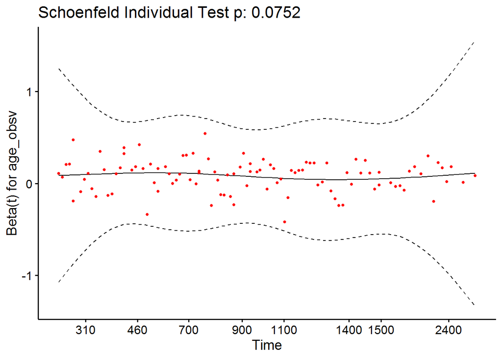